# Description

This notebook brings together the notebooks for RNN and LinCRF.

The objective is to find out how different models behave on the extraction, which parameters and ensembles to use.

Given:

- Simple NN
- Complex NN
- RNN
- Random Forest (RF)
- Feature sets A (190 features) and B (150 features)

Test:

- Effects of undersampling unassigned elements during training
- For 20% undersampling, test effects of using feature set A and B (on Simple NN, RNN, RF)
- Postprocessing
  - precision/recall threshold adjustment
  - inst max
  - inst max per plabel
  - exclude author combinations

```python
%reload_ext autoreload
%autoreload 2
import matplotlib.pyplot as plt
import numpy as np
import pandas as pd
import numpy.random
import sklearn
from sms_pandas import DataHolder
from sms_pandas import label_dict
from pprint import pprint

def print_full(x, cols=None):
    pd.set_option('display.max_rows', len(x))
    if cols:
        print(x[cols])
    else:
        print(x)
    pd.reset_option('display.max_rows')
```

```python
mask_params = {'exclude_origin': True, 'exclude_neg': True, 'exclude_outside_x': True, 'exclude_outside_y': True,
               'exclude_zero_width': True, 'exclude_zero_height': True, 'exclude_large_height': True,
               'exclude_large_width':True, 'exclude_onechar': True, 'exclude_twochar': True,
               'exclude_threechar': True, 'has_title': True, 'has_author': False, 'has_issued': False,
               'spread': True}

holdere = DataHolder('../evalset', fix_labeling=False, from_fix=True, fix_fix=False, create_features=True,
                    tmp_folder='../tmp_eval', features_from_tmp=True, add_neighbourhoods=True,
                    reload_tmp=False, mask_params=mask_params, threads=20)

raw_framee = holdere.get_raw_frame()
meta_framee = holdere.get_meta_frame()
feature_framee = holdere.get_feature_frame()

maske = holdere.get_mask(**mask_params)

print("All initialised!")
```

```
reading json files...
1.1639830270000004
loading frames from tmp...
reading raw frame...
fixing arrays in frame...
reading meta frame...
2.0843437710000003
loading features from tmp...
DataHolder initialised. ( 3.361704411 )
All initialised!
```

```python
# Data init
mask_params = {'exclude_origin': True, 'exclude_neg': True, 'exclude_outside_x': True, 'exclude_outside_y': True,
               'exclude_zero_width': True, 'exclude_zero_height': True, 'exclude_large_height': True,
               'exclude_large_width':True, 'exclude_onechar': True, 'exclude_twochar': True,
               'exclude_threechar': True, 'has_title': True, 'has_author': False, 'has_issued': False,
               'spread': True}

holder = DataHolder('../learnbase', fix_labeling=False, from_fix=True, create_features=True,
                    tmp_folder='../tmp', features_from_tmp=True, add_neighbourhoods=True,
                    reload_tmp=False, mask_params=mask_params, threads=20)

raw_frame = holder.get_raw_frame()
meta_frame = holder.get_meta_frame()
feature_frame = holder.get_feature_frame()

mask = holder.get_mask(**mask_params)

# list the dictionaries for reference
print("Features:")
print(feature_frame.columns)
print("Labels:")
print(label_dict)

print("All initialised!")
```

```
reading json files...
7.044272446000001
loading frames from tmp...
reading raw frame...
fixing arrays in frame...
reading meta frame...
16.303953536
loading features from tmp...
DataHolder initialised. ( 24.461021366999997 )
Features:
Index(['area', 'background_color', 'background_color_b', 'background_color_g',
       'background_color_r', 'center_x_raw', 'center_y_raw', 'contains_month',
       'contains_short_month', 'css_height',
       ...
       'v_pos_standardised', 'width_prel', 'width_prel<10', 'width_prel<20',
       'width_prel<30', 'width_prel<40', 'width_prel<50', 'width_prel>50',
       'width_rescaled', 'width_standardised'],
      dtype='object', length=273)
Labels:
['TITLE', 'AUTHOR', 'ISSUED', 'UNASSIGNED']
All initialised!
```

```python
%matplotlib inline
from sklearn.metrics import precision_recall_curve, auc, f1_score

def pr_curve(y, preds):
    plt.clf()
    for i, f in enumerate(['title','author','date','unassigned']):
        prec, rec, thresh = precision_recall_curve(y==i, preds[:,i])
        f1 = (2*(prec*rec)/(prec+rec))
        bestf1 = f1.argmax()
        t = thresh[f1.argmax()]
        auc_ = auc(rec, prec)

        plt.plot(rec,prec, label=f)

        if 0 < i < 3:
            displacex = 0.1 if i == 1 else 0.02
            displacey = 0.2

            plt.annotate('F1:{:.2}\nAUC: {:.2}\nT: {:.2}'.format(f1[bestf1],auc_,t),
                        xy=(rec[bestf1],prec[bestf1]),
                        xytext=(rec[bestf1]-displacex,prec[bestf1]-displacey),
                        arrowprops=dict(arrowstyle="->"),
                        ha='right',
                        va='top')
        if i == 0:
            plt.annotate('F1:{:.2}\nAUC: {:.2}\nT: {:.2}'.format(f1[bestf1],auc_,t),
                         xy=(rec[bestf1],prec[bestf1]),
                         xytext=(rec[bestf1]+0.05,prec[bestf1]),
                         arrowprops=dict(arrowstyle="->"),
                         ha='left')

    plt.ylabel('Precision')
    plt.xlabel('Recall')
    plt.ylim(0,1.1)
    plt.xlim(0,1.1)
    plt.legend(loc='upper left', bbox_to_anchor=(1.05, 1))
    plt.grid()
    plt.show()
```

```python
from sklearn.metrics import precision_recall_curve
def doeval(pred, ytst, frm, raw, cnt):
    fram = eva.get_predictframe(pred, global_idxmax=True, plabel_idxmax=True, testfrm=frm)

    print('raw')
    eva.measure_performance(None, ytst, pred)
    #print('idxmax')
    #eva.measure_performance(None, y_testa, list(fram['gilabel']))
    #print('plabel idxmax')
    #eva.measure_performance(None, y_testa, list(fram['ilabel']))

    pr_curve(ytst, pred)

    ps = pd.Series([3]*len(fram), index=fram.index)

    prec, rec, thresh = precision_recall_curve(ytst==0, pred[:,0])
    f1 = (2*(prec*rec)/(prec+rec))
    bestf1 = np.nanargmax(f1)
    t = thresh[bestf1]
    print(t)
    ps.loc[list(fram[fram['title']>t].groupby('instance').idxmax()['title'])] = 0

    prec, rec, thresh = precision_recall_curve(ytst==1, pred[:,1])
    f1 = (2*(prec*rec)/(prec+rec))
    bestf1 = np.nanargmax(f1)
    t = thresh[bestf1]
    print(t)
    cnt_frm_ = cnt_frm.loc[fram[(fram['author']>t)].index]
    ps.loc[fram[(fram['author']>t)&(cnt_frm_['score']<40)].index] = 1

    prec, rec, thresh = precision_recall_curve(ytst==2, pred[:,2])
    f1 = (2*(prec*rec)/(prec+rec))
    bestf1 = np.nanargmax(f1)
    t = thresh[bestf1]
    print(t)
    ps.loc[list(fram[(~raw['text'].str.contains(r'\d{4}.+?\d{4}'))&
           (~raw['text'].str.contains(r'(?:^|\D)\d{3}(?:\D|$)'))&
           (fram['issued']>t)].groupby('instance').idxmax()['issued'])] = 2

    eva.measure_performance(None, ytst, list(ps))
    return ps, fram
```

```python
feature_weights_a = {
    "area": 0.0,
    "area_rescaled": 1.0,
    "area_standardised": 1.0,
    "avg_neighbourdist_k=1": 0.0,
    "avg_neighbourdist_k=2": 0.0,
    "avg_neighbourdist_k=2<110.0": 1.0,
    "avg_neighbourdist_k=2<145.0": 1.0,
    "avg_neighbourdist_k=2<180.0": 1.0,
    "avg_neighbourdist_k=2<220.0": 1.0,
    "avg_neighbourdist_k=2<45.0": 1.0,
    "avg_neighbourdist_k=2<80.0": 1.0,
    "avg_neighbourdist_k=2>220.0": 1.0,
    "avg_neighbourdist_k=3": 0.0,
    "avg_neighbourdist_k=4": 0.0,
    "avg_neighbourdist_k=4<100.0": 1.0,
    "avg_neighbourdist_k=4<170.0": 1.0,
    "avg_neighbourdist_k=4<210.0": 1.0,
    "avg_neighbourdist_k=4<250.0": 1.0,
    "avg_neighbourdist_k=4<300.0": 1.0,
    "avg_neighbourdist_k=4<60.0": 1.0,
    "avg_neighbourdist_k=4>300.0": 1.0,
    "avg_neighbourdist_k=5": 0.0,
    "background_color": 0.0,
    "background_color_b": 0.0,
    "background_color_g": 0.0,
    "background_color_r": 0.0,
    "center_x": 0.0,
    "center_x_raw": 0.0,
    "center_y": 0.0,
    "center_y_raw": 0.0,
    "contains_month": 1.0,
    "contains_short_month": 1.0,
    "css_height": 0.0,
    "css_height_rel": 0.0,
    "css_width": 0.0,
    "css_width_rel": 0.0,
    "first_word=by": 1.0,
    "first_word=last_update": 1.0,
    "first_word=posted": 1.0,
    "font_family=mono": 1.0,
    "font_family=sans": 1.0,
    "font_family=serif": 1.0,
    "font_size": 0.0,
    "font_size<<mean": 1.0,
    "font_size<mean": 1.0,
    "font_size=10": 1.0,
    "font_size=11": 1.0,
    "font_size=12": 1.0,
    "font_size=13": 1.0,
    "font_size=14": 1.0,
    "font_size=15": 1.0,
    "font_size=16": 1.0,
    "font_size=17": 1.0,
    "font_size=18": 1.0,
    "font_size=19": 1.0,
    "font_size=20": 1.0,
    "font_size=21": 1.0,
    "font_size=22": 1.0,
    "font_size=23": 1.0,
    "font_size=24": 1.0,
    "font_size=25_29": 1.0,
    "font_size=30_34": 1.0,
    "font_size=35_40": 1.0,
    "font_size=8": 1.0,
    "font_size=9": 1.0,
    "font_size==mean": 1.0,
    "font_size=gt40": 1.0,
    "font_size=lt8": 1.0,
    "font_size=mean": 1.0,
    "font_size>>mean": 1.0,
    "font_size>mean": 1.0,
    "font_size_diff": 0.0,
    "font_size_rescaled": 1.0,
    "font_size_standardised": 1.0,
    "font_style=italic": 1.0,
    "font_style=normal": 1.0,
    "font_style_fam=italic": 1.0,
    "font_style_fam=normal": 1.0,
    "font_weight=bold": 1.0,
    "font_weight=normal": 1.0,
    "font_weight_fam=bold": 1.0,
    "font_weight_fam=normal": 1.0,
    "h_pos": 0.0,
    "h_pos_clipped": 0.0,
    "h_pos_clipped_right": 0.0,
    "h_pos_from_mean": 0.0,
    "h_pos_from_mean=-20--5": 1.0,
    "h_pos_from_mean=-35--20": 1.0,
    "h_pos_from_mean=-5-5": 1.0,
    "h_pos_from_mean=-50--35": 1.0,
    "h_pos_from_mean=20-35": 1.0,
    "h_pos_from_mean=35-50": 1.0,
    "h_pos_from_mean=5-20": 1.0,
    "h_pos_prel": 0.0,
    "h_pos_rel": 0.0,
    "h_pos_rel_from_mean": 0.0,
    "h_pos_rescaled": 1.0,
    "h_pos_right": 0.0,
    "h_pos_standardised": 1.0,
    "h_tag": 1.0,
    "has_abbrev_name": 1.0,
    "has_academic_title": 1.0,
    "has_am_pm": 0.0,
    "has_background_color=black": 1.0,
    "has_background_color=white": 1.0,
    "has_background_image": 1.0,
    "has_consec_digits=2": 0.0,
    "has_consec_digits=4": 1.0,
    "has_dateformat=a": 1.0,
    "has_dateformat=b": 1.0,
    "has_dateformat=c": 1.0,
    "has_dateformat=d": 1.0,
    "has_dateformat=e": 1.0,
    "has_daytime": 0.0,
    "has_digits": 0.0,
    "has_dots": 1.0,
    "has_id": 1.0,
    "has_linebreaks": 1.0,
    "has_rules": 0.0,
    "has_typical_name_form": 0.0,
    "has_uppercase": 1.0,
    "height": 0.0,
    "height_rel": 0.0,
    "height_rescaled": 1.0,
    "height_standardised": 1.0,
    "hw_ratio": 0.0,
    "hw_ratio=land_slim": 1.0,
    "hw_ratio=land_slim<0.08": 1.0,
    "hw_ratio=land_slim<0.15": 1.0,
    "hw_ratio=land_slim<0.25": 1.0,
    "hw_ratio=landscape": 1.0,
    "hw_ratio=port_slim": 1.0,
    "hw_ratio=portrait": 1.0,
    "hw_ratio=square": 1.0,
    "id_group=author": 1.0,
    "id_group=issued": 1.0,
    "id_group=none": 1.0,
    "id_group=title": 1.0,
    "in_quadrant=00": 1.0,
    "in_quadrant=01": 1.0,
    "in_quadrant=10": 1.0,
    "in_quadrant=11": 1.0,
    "in_screen=1": 1.0,
    "in_screen=2": 1.0,
    "in_screen=3": 1.0,
    "in_screen=4": 1.0,
    "in_screen=5": 1.0,
    "in_screen=6": 1.0,
    "in_screen>6": 1.0,
    "in_top_20": 1.0,
    "in_top_40": 1.0,
    "in_top_60": 1.0,
    "instance": 0.0,
    "is_largest_font": 1.0,
    "is_second_largest_font": 1.0,
    "is_smallest_font": 1.0,
    "label": 0.0,
    "margin_bottom": 0.0,
    "margin_left": 0.0,
    "margin_right": 0.0,
    "margin_top": 0.0,
    "nb_font_size<<mean": 1.0,
    "nb_font_size<mean": 1.0,
    "nb_font_size==mean": 1.0,
    "nb_font_size=mean": 1.0,
    "nb_font_size>>mean": 1.0,
    "nb_font_size>mean": 1.0,
    "nb_font_size_diff": 1.0,
    "node_type=a": 1.0,
    "node_type=b": 1.0,
    "node_type=big": 0.0,
    "node_type=button": 0.0,
    "node_type=cite": 1.0,
    "node_type=data": 0.0,
    "node_type=dd": 0.0,
    "node_type=div": 1.0,
    "node_type=dt": 0.0,
    "node_type=em": 0.0,
    "node_type=figcaption": 0.0,
    "node_type=font": 0.0,
    "node_type=h1": 1.0,
    "node_type=h2": 1.0,
    "node_type=h3": 1.0,
    "node_type=h4": 0.0,
    "node_type=h5": 0.0,
    "node_type=h6": 0.0,
    "node_type=i": 0.0,
    "node_type=label": 0.0,
    "node_type=li": 0.0,
    "node_type=nobr": 0.0,
    "node_type=p": 1.0,
    "node_type=small": 1.0,
    "node_type=span": 1.0,
    "node_type=strong": 1.0,
    "node_type=td": 1.0,
    "node_type=th": 1.0,
    "node_type=time": 1.0,
    "node_type=u": 1.0,
    "not_top_40": 1.0,
    "not_top_60": 1.0,
    "num_chars<30": 1.0,
    "num_chars<64": 1.0,
    "num_chars<8": 1.0,
    "num_chars<96": 1.0,
    "num_chars>96": 1.0,
    "num_commas": 1.0,
    "num_dashes": 1.0,
    "num_digits": 1.0,
    "num_dots": 1.0,
    "num_linebreaks": 1.0,
    "num_semicolons": 1.0,
    "num_slashes": 1.0,
    "num_uppercase_chars": 1.0,
    "num_uppercase_words": 0.0,
    "num_uppercase_words=1": 1.0,
    "num_uppercase_words=2": 1.0,
    "num_uppercase_words=3": 1.0,
    "num_uppercase_words=3-5": 1.0,
    "num_uppercase_words=5-8": 1.0,
    "num_uppercase_words=8-12": 1.0,
    "num_uppercase_words>12": 1.0,
    "num_words": 0.0,
    "num_words=1": 1.0,
    "num_words=2": 1.0,
    "num_words=3": 1.0,
    "num_words=3-5": 1.0,
    "num_words=5-8": 1.0,
    "num_words=8-12": 1.0,
    "num_words>12": 1.0,
    "num_words_rescaled": 1.0,
    "num_words_standardised": 1.0,
    "padding_bottom": 0.0,
    "padding_left": 0.0,
    "padding_right": 0.0,
    "padding_top": 0.0,
    "page_area": 0.0,
    "page_v_screenspan": 0.0,
    "screen_area": 0.0,
    "space_bottom": 0.0,
    "space_left": 0.0,
    "space_right": 0.0,
    "space_top": 0.0,
    "text_align=center": 1.0,
    "text_align=justify": 1.0,
    "text_align=left": 1.0,
    "text_align=right": 1.0,
    "text_length": 0.0,
    "text_length_rescaled": 1.0,
    "v_pos": 0.0,
    "v_pos_bottom": 0.0,
    "v_pos_clipped": 0.0,
    "v_pos_clipped_bottom": 0.0,
    "v_pos_prel": 0.0,
    "v_pos_rel": 0.0,
    "v_pos_rescaled": 1.0,
    "v_pos_srel": 0.0,
    "v_pos_standardised": 1.0,
    "width": 0.0,
    "width_prel": 0.0,
    "width_prel<10": 1.0,
    "width_prel<20": 1.0,
    "width_prel<30": 1.0,
    "width_prel<40": 1.0,
    "width_prel<50": 1.0,
    "width_prel>50": 1.0,
    "width_rel": 0.0,
    "width_rel<10": 1.0,
    "width_rel<20": 1.0,
    "width_rel<30": 1.0,
    "width_rel<40": 1.0,
    "width_rel>40": 1.0,
    "width_rescaled": 1.0,
    "width_standardised": 1.0
}
```

```python
feature_weights_b = {
    "area": 0.0,
    "area_rescaled": 1.0,
    "area_standardised": 1.0,
    "avg_neighbourdist_k=1": 0.0,
    "avg_neighbourdist_k=2": 0.0,
    "avg_neighbourdist_k=2<110.0": 1.0,
    "avg_neighbourdist_k=2<145.0": 1.0,
    "avg_neighbourdist_k=2<180.0": 1.0,
    "avg_neighbourdist_k=2<220.0": 1.0,
    "avg_neighbourdist_k=2<45.0": 1.0,
    "avg_neighbourdist_k=2<80.0": 1.0,
    "avg_neighbourdist_k=2>220.0": 1.0,
    "avg_neighbourdist_k=3": 0.0,
    "avg_neighbourdist_k=4": 0.0,
    "avg_neighbourdist_k=4<100.0": 1.0,
    "avg_neighbourdist_k=4<170.0": 1.0,
    "avg_neighbourdist_k=4<210.0": 1.0,
    "avg_neighbourdist_k=4<250.0": 1.0,
    "avg_neighbourdist_k=4<300.0": 1.0,
    "avg_neighbourdist_k=4<60.0": 1.0,
    "avg_neighbourdist_k=4>300.0": 1.0,
    "avg_neighbourdist_k=5": 0.0,
    "background_color": 0.0,
    "background_color_b": 0.0,
    "background_color_g": 0.0,
    "background_color_r": 0.0,
    "center_x": 0.0,
    "center_x_raw": 0.0,
    "center_y": 0.0,
    "center_y_raw": 0.0,
    "contains_month": 1.0,
    "contains_short_month": 1.0,
    "css_height": 0.0,
    "css_height_rel": 0.0,
    "css_width": 0.0,
    "css_width_rel": 0.0,
    "first_word=by": 1.0,
    "first_word=last_update": 1.0,
    "first_word=posted": 1.0,
    "font_family=mono": 0.0,
    "font_family=sans": 1.0,
    "font_family=serif": 1.0,
    "font_size": 0.0,
    "font_size<<mean": 1.0,
    "font_size<mean": 1.0,
    "font_size=10": 0.0,
    "font_size=11": 0.0,
    "font_size=12": 0.0,
    "font_size=13": 0.0,
    "font_size=14": 0.0,
    "font_size=15": 0.0,
    "font_size=16": 0.0,
    "font_size=17": 0.0,
    "font_size=18": 0.0,
    "font_size=19": 0.0,
    "font_size=20": 0.0,
    "font_size=21": 0.0,
    "font_size=22": 0.0,
    "font_size=23": 0.0,
    "font_size=24": 0.0,
    "font_size=25_29": 0.0,
    "font_size=30_34": 0.0,
    "font_size=35_40": 0.0,
    "font_size=8": 0.0,
    "font_size=9": 0.0,
    "font_size==mean": 1.0,
    "font_size=gt40": 0.0,
    "font_size=lt8": 0.0,
    "font_size=mean": 1.0,
    "font_size>>mean": 1.0,
    "font_size>mean": 1.0,
    "font_size_diff": 0.0,
    "font_size_rescaled": 1.0,
    "font_size_standardised": 1.0,
    "font_style=italic": 1.0,
    "font_style=normal": 1.0,
    "font_style_fam=italic": 0.0,
    "font_style_fam=normal": 0.0,
    "font_weight=bold": 1.0,
    "font_weight=normal": 1.0,
    "font_weight_fam=bold": 0.0,
    "font_weight_fam=normal": 0.0,
    "h_pos": 0.0,
    "h_pos_clipped": 0.0,
    "h_pos_clipped_right": 0.0,
    "h_pos_from_mean": 0.0,
    "h_pos_from_mean=-20--5": 1.0,
    "h_pos_from_mean=-35--20": 1.0,
    "h_pos_from_mean=-5-5": 1.0,
    "h_pos_from_mean=-50--35": 1.0,
    "h_pos_from_mean=20-35": 1.0,
    "h_pos_from_mean=35-50": 1.0,
    "h_pos_from_mean=5-20": 1.0,
    "h_pos_prel": 0.0,
    "h_pos_rel": 0.0,
    "h_pos_rel_from_mean": 0.0,
    "h_pos_rescaled": 1.0,
    "h_pos_right": 0.0,
    "h_pos_standardised": 1.0,
    "h_tag": 1.0,
    "has_abbrev_name": 1.0,
    "has_academic_title": 1.0,
    "has_am_pm": 0.0,
    "has_background_color=black": 0.0,
    "has_background_color=white": 1.0,
    "has_background_image": 1.0,
    "has_consec_digits=2": 0.0,
    "has_consec_digits=4": 1.0,
    "has_dateformat=a": 1.0,
    "has_dateformat=b": 1.0,
    "has_dateformat=c": 1.0,
    "has_dateformat=d": 1.0,
    "has_dateformat=e": 1.0,
    "has_daytime": 0.0,
    "has_digits": 0.0,
    "has_dots": 1.0,
    "has_id": 0.0,
    "has_linebreaks": 1.0,
    "has_rules": 0.0,
    "has_typical_name_form": 0.0,
    "has_uppercase": 1.0,
    "height": 0.0,
    "height_rel": 0.0,
    "height_rescaled": 1.0,
    "height_standardised": 1.0,
    "hw_ratio": 0.0,
    "hw_ratio=land_slim": 1.0,
    "hw_ratio=land_slim<0.08": 1.0,
    "hw_ratio=land_slim<0.15": 1.0,
    "hw_ratio=land_slim<0.25": 1.0,
    "hw_ratio=landscape": 1.0,
    "hw_ratio=port_slim": 0.0,
    "hw_ratio=portrait": 1.0,
    "hw_ratio=square": 1.0,
    "id_group=author": 0.0,
    "id_group=issued": 0.0,
    "id_group=none": 0.0,
    "id_group=title": 0.0,
    "in_quadrant=00": 1.0,
    "in_quadrant=01": 1.0,
    "in_quadrant=10": 1.0,
    "in_quadrant=11": 1.0,
    "in_screen=1": 1.0,
    "in_screen=2": 1.0,
    "in_screen=3": 1.0,
    "in_screen=4": 1.0,
    "in_screen=5": 1.0,
    "in_screen=6": 1.0,
    "in_screen>6": 1.0,
    "in_top_20": 1.0,
    "in_top_40": 1.0,
    "in_top_60": 1.0,
    "instance": 0.0,
    "is_largest_font": 1.0,
    "is_second_largest_font": 1.0,
    "is_smallest_font": 1.0,
    "label": 0.0,
    "margin_bottom": 0.0,
    "margin_left": 0.0,
    "margin_right": 0.0,
    "margin_top": 0.0,
    "nb_font_size<<mean": 1.0,
    "nb_font_size<mean": 1.0,
    "nb_font_size==mean": 1.0,
    "nb_font_size=mean": 1.0,
    "nb_font_size>>mean": 1.0,
    "nb_font_size>mean": 1.0,
    "nb_font_size_diff": 1.0,
    "node_type=a": 1.0,
    "node_type=b": 1.0,
    "node_type=big": 0.0,
    "node_type=button": 0.0,
    "node_type=cite": 1.0,
    "node_type=data": 0.0,
    "node_type=dd": 0.0,
    "node_type=div": 1.0,
    "node_type=dt": 0.0,
    "node_type=em": 0.0,
    "node_type=figcaption": 0.0,
    "node_type=font": 0.0,
    "node_type=h1": 1.0,
    "node_type=h2": 1.0,
    "node_type=h3": 1.0,
    "node_type=h4": 0.0,
    "node_type=h5": 0.0,
    "node_type=h6": 0.0,
    "node_type=i": 0.0,
    "node_type=label": 0.0,
    "node_type=li": 0.0,
    "node_type=nobr": 0.0,
    "node_type=p": 1.0,
    "node_type=small": 1.0,
    "node_type=span": 1.0,
    "node_type=strong": 1.0,
    "node_type=td": 1.0,
    "node_type=th": 1.0,
    "node_type=time": 1.0,
    "node_type=u": 1.0,
    "not_top_40": 0.0,
    "not_top_60": 1.0,
    "num_chars<30": 1.0,
    "num_chars<64": 1.0,
    "num_chars<8": 1.0,
    "num_chars<96": 1.0,
    "num_chars>96": 1.0,
    "num_commas": 1.0,
    "num_dashes": 1.0,
    "num_digits": 1.0,
    "num_dots": 1.0,
    "num_linebreaks": 1.0,
    "num_semicolons": 1.0,
    "num_slashes": 1.0,
    "num_uppercase_chars": 1.0,
    "num_uppercase_words": 0.0,
    "num_uppercase_words=1": 1.0,
    "num_uppercase_words=2": 1.0,
    "num_uppercase_words=3": 1.0,
    "num_uppercase_words=3-5": 1.0,
    "num_uppercase_words=5-8": 1.0,
    "num_uppercase_words=8-12": 1.0,
    "num_uppercase_words>12": 1.0,
    "num_words": 0.0,
    "num_words=1": 0.0,
    "num_words=2": 0.0,
    "num_words=3": 0.0,
    "num_words=3-5": 0.0,
    "num_words=5-8": 0.0,
    "num_words=8-12": 0.0,
    "num_words>12": 0.0,
    "num_words_rescaled": 1.0,
    "num_words_standardised": 1.0,
    "padding_bottom": 0.0,
    "padding_left": 0.0,
    "padding_right": 0.0,
    "padding_top": 0.0,
    "page_area": 0.0,
    "page_v_screenspan": 0.0,
    "screen_area": 0.0,
    "space_bottom": 0.0,
    "space_left": 0.0,
    "space_right": 0.0,
    "space_top": 0.0,
    "text_align=center": 1.0,
    "text_align=justify": 1.0,
    "text_align=left": 1.0,
    "text_align=right": 1.0,
    "text_length": 0.0,
    "text_length_rescaled": 1.0,
    "v_pos": 0.0,
    "v_pos_bottom": 0.0,
    "v_pos_clipped": 0.0,
    "v_pos_clipped_bottom": 0.0,
    "v_pos_prel": 0.0,
    "v_pos_rel": 0.0,
    "v_pos_rescaled": 1.0,
    "v_pos_srel": 0.0,
    "v_pos_standardised": 1.0,
    "width": 0.0,
    "width_prel": 0.0,
    "width_prel<10": 1.0,
    "width_prel<20": 1.0,
    "width_prel<30": 1.0,
    "width_prel<40": 1.0,
    "width_prel<50": 1.0,
    "width_prel>50": 1.0,
    "width_rel": 0.0,
    "width_rel<10": 1.0,
    "width_rel<20": 1.0,
    "width_rel<30": 1.0,
    "width_rel<40": 1.0,
    "width_rel>40": 1.0,
    "width_rescaled": 1.0,
    "width_standardised": 1.0
}
```

```python
from sms_eval import Evaluator

unassigned_reduction = 0.20
neighbourhood_size = 10

eva_a = (Evaluator(feature_frame, mask, feature_weights_a),)
eva_a = eva_a + (eva_a[0].get_keep_features(),)
eva_a = eva_a + eva_a[0].get_traintest_i_flat(reduction_min=4,
                                              reduction=unassigned_reduction)

eva_b = (Evaluator(feature_frame, mask, feature_weights_b),)
eva_b = eva_b + (eva_b[0].get_keep_features(),)
eva_b = eva_b + eva_b[0].get_traintest_i_flat(reduction_min=4, reduction=unassigned_reduction)

eva, keep_features, test, train, X_train, y_train, Y_train, X_test, y_test, Y_test, nb_classes, class_weights = eva_a

eva_a_rf = (Evaluator(feature_frame, mask, feature_weights_a),)
eva_a_rf = eva_a_rf + (eva_a_rf[0].get_keep_features(),)
eva_a_rf = eva_a_rf + eva_a_rf[0].get_traintest_i_flat(reduction_min=4,
                                              reduction=0.6,
                                              testsetfix=list(set(test['instance'])))
```

```
num features in frame 273
num feature weights 273
num selected features 191
num instances 683
num train instances 479 , rows: 13154
num test instances 204 , rows: 24479
num features in frame 273
num feature weights 273
num selected features 149
num instances 683
num train instances 479 , rows: 13118
num test instances 204 , rows: 24611
num features in frame 273
num feature weights 273
num selected features 191
num instances 683
num train instances 479 , rows: 37403
num test instances 204 , rows: 24479
```

```python
eva, keep_features, test, train, X_train, y_train, Y_train, X_test, y_test, Y_test, nb_classes, class_weights = eva_b

eva_b_rf = (Evaluator(feature_frame, mask, feature_weights_b),)
eva_b_rf = eva_b_rf + (eva_b_rf[0].get_keep_features(),)
eva_b_rf = eva_b_rf + eva_b_rf[0].get_traintest_i_flat(reduction_min=4,
                                              reduction=0.6,
                                              testsetfix=list(set(test['instance'])))
```

```
num features in frame 273
num feature weights 273
num selected features 149
num instances 683
num train instances 479 , rows: 37316
num test instances 204 , rows: 24611
```

```python
eva, keep_features, test, train, X_train, y_train, Y_train, X_test, y_test, Y_test, nb_classes, class_weights = eva_b

neighbourhood_size=10
eva_b_rnn = (Evaluator(feature_frame, mask, feature_weights_b),)
eva_b_rnn = eva_b_rnn + (eva_b_rnn[0].get_keep_features(),)
eva_b_rnn = eva_b_rnn + eva_b_rnn[0].get_traintest_nn(nb_neigh=(neighbourhood_size-1),
                                                      reduction_min=neighbourhood_size,
                                                      reverse=True,
                                                      flat_y=True,
                                                      reduction=0.8,
                                                      testsetfix=list(set(test['instance'])))
```

```
num features in frame 273
num feature weights 273
num selected features 149
num instances 683
num train instances 479 , rows: 49426
num test instances 204 , rows: 24611
```

```python
tmpa = [k for k,v in feature_weights_a.items() if v > 0]
tmpb = [k for k,v in feature_weights_b.items() if v > 0]

for f in list(feature_frame.columns):
    fs = []
    if f in tmpa:
        fs.append('\Phi^A')
    if f in tmpb:
        fs.append('\Phi^B')
    if len(fs) == 0:
        fs = ['-']

    print('\\texttt{{{}}}\t ${}$'.format(f, ','.join(fs)))
```

```
\texttt{area}	 $-$
\texttt{background_color}	 $-$
\texttt{background_color_b}	 $-$
\texttt{background_color_g}	 $-$
\texttt{background_color_r}	 $-$
\texttt{center_x_raw}	 $-$
\texttt{center_y_raw}	 $-$
\texttt{contains_month}	 $\Phi^A,\Phi^B$
\texttt{contains_short_month}	 $\Phi^A,\Phi^B$
\texttt{css_height}	 $-$
\texttt{css_height_rel}	 $-$
\texttt{css_width}	 $-$
\texttt{css_width_rel}	 $-$
\texttt{first_word=by}	 $\Phi^A,\Phi^B$
\texttt{first_word=last_update}	 $\Phi^A,\Phi^B$
\texttt{first_word=posted}	 $\Phi^A,\Phi^B$
\texttt{font_family=sans}	 $\Phi^A,\Phi^B$
\texttt{font_family=serif}	 $\Phi^A,\Phi^B$
\texttt{font_size}	 $-$
\texttt{font_size=10}	 $\Phi^A$
\texttt{font_size=11}	 $\Phi^A$
\texttt{font_size=12}	 $\Phi^A$
\texttt{font_size=13}	 $\Phi^A$
\texttt{font_size=14}	 $\Phi^A$
\texttt{font_size=15}	 $\Phi^A$
\texttt{font_size=16}	 $\Phi^A$
\texttt{font_size=17}	 $\Phi^A$
\texttt{font_size=18}	 $\Phi^A$
\texttt{font_size=19}	 $\Phi^A$
\texttt{font_size=20}	 $\Phi^A$
\texttt{font_size=21}	 $\Phi^A$
\texttt{font_size=22}	 $\Phi^A$
\texttt{font_size=23}	 $\Phi^A$
\texttt{font_size=24}	 $\Phi^A$
\texttt{font_size=25_29}	 $\Phi^A$
\texttt{font_size=30_34}	 $\Phi^A$
\texttt{font_size=35_40}	 $\Phi^A$
\texttt{font_size=8}	 $\Phi^A$
\texttt{font_size=9}	 $\Phi^A$
\texttt{font_size=gt40}	 $\Phi^A$
```

[output cut: 214 more lines]

```
\texttt{text_length_rescaled}	 $\Phi^A,\Phi^B$
\texttt{v_pos_clipped}	 $-$
\texttt{v_pos_clipped_bottom}	 $-$
\texttt{v_pos_prel}	 $-$
\texttt{v_pos_rescaled}	 $\Phi^A,\Phi^B$
\texttt{v_pos_standardised}	 $\Phi^A,\Phi^B$
\texttt{width_prel}	 $-$
\texttt{width_prel<10}	 $\Phi^A,\Phi^B$
\texttt{width_prel<20}	 $\Phi^A,\Phi^B$
\texttt{width_prel<30}	 $\Phi^A,\Phi^B$
\texttt{width_prel<40}	 $\Phi^A,\Phi^B$
\texttt{width_prel<50}	 $\Phi^A,\Phi^B$
\texttt{width_prel>50}	 $\Phi^A,\Phi^B$
\texttt{width_rescaled}	 $\Phi^A,\Phi^B$
\texttt{width_standardised}	 $\Phi^A,\Phi^B$
```

# Simple NN

```
Accuracy:0.897
             precision    recall  f1-score   support

      title       0.28      0.97      0.44        96
     author       0.05      0.84      0.09        51
       date       0.17      0.89      0.28        46
 unassigned       1.00      0.90      0.94     12601

avg / total       0.99      0.90      0.94     12794

[[   93     0     0     3]
 [    2    43     2     4]
 [    0     0    41     5]
 [  235   869   200 11297]]
```

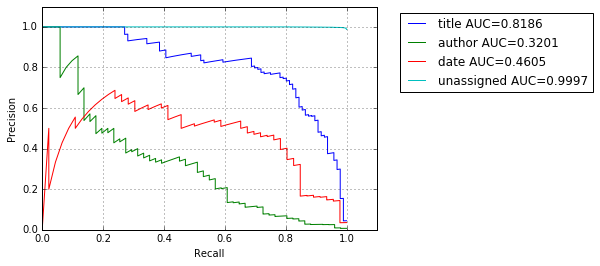

```python
eva.measure_performance(None, np.array(feature_frame[mask]['label']), basd, show_curves=True)
```

```python
eva, keep_features, test, train, X_train, y_train, Y_train, X_test, y_test, Y_test, nb_classes, class_weights = eva_b
```

```python
from keras.models import Sequential
from keras.layers.core import Dense, Activation, Dropout
from keras.layers.advanced_activations import LeakyReLU
from keras.regularizers import l2, activity_l2
from keras.utils import np_utils
from sklearn.multiclass import OneVsRestClassifier
import keras.optimizers as opts
from keras.callbacks import TensorBoard

nb_epoch = 25
batch_size = 10
val_data_size = 50

model_nn1 = Sequential()
model_nn1.add(Dense(output_dim=len(keep_features), input_dim=len(keep_features), init='he_uniform'))
model_nn1.add(Activation("linear"))

model_nn1.add(Dense(80, W_regularizer=l2(0.01), init='he_uniform'))
model_nn1.add(Activation("softsign"))
model_nn1.add(Dropout(0.4))

model_nn1.add(Dense(35, W_regularizer=l2(0.01), init='he_uniform'))
model_nn1.add(Activation("softsign"))
model_nn1.add(Dropout(0.2))

model_nn1.add(Dense(nb_classes, init='he_uniform'))
model_nn1.add(Activation("softmax"))

model_nn1.summary()

model_nn1.compile(loss='msle',
              optimizer=opts.Adadelta(),
              metrics=['accuracy'])

history_nn1 = model_nn1.fit(X_train, Y_train,
                    batch_size=batch_size,
                    nb_epoch=nb_epoch,
                    class_weight=class_weights,
                    verbose=1,
                    validation_data=(X_test[:val_data_size], Y_test[:val_data_size]))
print('done')
```

```
____________________________________________________________________________________________________
Layer (type)                     Output Shape          Param #     Connected to
====================================================================================================
dense_1 (Dense)                  (None, 149)           22350       dense_input_1[0][0]
____________________________________________________________________________________________________
activation_1 (Activation)        (None, 149)           0           dense_1[0][0]
____________________________________________________________________________________________________
dense_2 (Dense)                  (None, 80)            12000       activation_1[0][0]
____________________________________________________________________________________________________
activation_2 (Activation)        (None, 80)            0           dense_2[0][0]
____________________________________________________________________________________________________
dropout_1 (Dropout)              (None, 80)            0           activation_2[0][0]
____________________________________________________________________________________________________
dense_3 (Dense)                  (None, 35)            2835        dropout_1[0][0]
____________________________________________________________________________________________________
activation_3 (Activation)        (None, 35)            0           dense_3[0][0]
____________________________________________________________________________________________________
dropout_2 (Dropout)              (None, 35)            0           activation_3[0][0]
____________________________________________________________________________________________________
dense_4 (Dense)                  (None, 4)             144         dropout_2[0][0]
____________________________________________________________________________________________________
activation_4 (Activation)        (None, 4)             0           dense_4[0][0]
====================================================================================================
Total params: 37329
____________________________________________________________________________________________________
Train on 13118 samples, validate on 50 samples
done
```

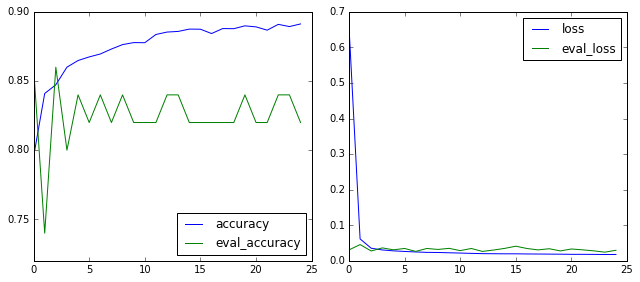

```
Accuracy:0.900
             precision    recall  f1-score   support

      title       0.50      0.96      0.66       204
     author       0.06      0.85      0.11       124
       date       0.16      0.97      0.27       103
 unassigned       1.00      0.90      0.95     24180

avg / total       0.99      0.90      0.94     24611

[[  196     3     1     4]
 [    1   106     3    14]
 [    0     0   100     3]
 [  197  1699   538 21746]]
```

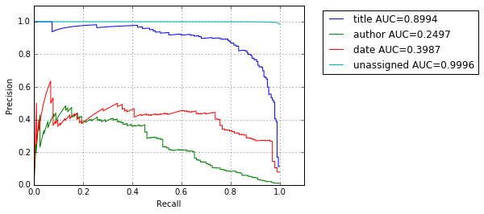

```
idxmax
Accuracy:0.983
             precision    recall  f1-score   support

      title       0.91      0.91      0.91       204
     author       0.24      0.40      0.30       124
       date       0.39      0.77      0.51       103
 unassigned       1.00      0.99      0.99     24180

avg / total       0.99      0.98      0.99     24611

[[  185     0     1    18]
 [    0    49     3    72]
 [    0     0    79    24]
 [   19   153   121 23887]]
plabel idxmax
Accuracy:0.985
             precision    recall  f1-score   support

      title       0.91      0.89      0.90       204
     author       0.24      0.40      0.30       124
       date       0.50      0.77      0.61       103
 unassigned       1.00      0.99      0.99     24180

avg / total       0.99      0.99      0.99     24611

[[  182     0     1    21]
 [    0    49     3    72]
 [    0     0    79    24]
 [   17   152    75 23936]]
```

```python
%matplotlib inline

eva.draw_traingraph(history_nn1)

predictions_nn1 = model_nn1.predict_proba(X_test)
predictframe_nn1 = eva.get_predictframe(predictions_nn1, global_idxmax=True, plabel_idxmax=True)

print('raw')
eva.measure_performance(None, y_test, predictions_nn1, show_curves=True)
print('idxmax')
eva.measure_performance(None, y_test, list(predictframe_nn1['gilabel']))
print('plabel idxmax')
eva.measure_performance(None, y_test, list(predictframe_nn1['ilabel']))
```

```python
from sklearn.metrics import precision_recall_curve
ps = pd.Series([3]*len(predictframe_nn1), index=predictframe_nn1.index)

prec, rec, thresh = precision_recall_curve(y_test==0, predictions_nn1[:,0])
ps.loc[predictframe_nn1['title']>thresh[np.argmax(prec>0.8)]] = 0

prec, rec, thresh = precision_recall_curve(y_test==1, predictions_nn1[:,1])
ps.loc[predictframe_nn1['author']>thresh[np.argmax(rec<0.6)]] = 1

prec, rec, thresh = precision_recall_curve(y_test==2, predictions_nn1[:,2])
ps.loc[predictframe_nn1['issued']>thresh[np.argmax(rec<0.65)]] = 2

eva.measure_performance(None, y_test, list(ps))
```

```
Accuracy:0.980
             precision    recall  f1-score   support

      title       0.80      0.79      0.80       204
     author       0.23      0.60      0.34       144
       date       0.53      0.65      0.58       110
 unassigned       0.99      0.98      0.99     25201

avg / total       0.99      0.98      0.98     25659

[[  162     0     0    42]
 [    0    86     2    56]
 [    0     0    71    39]
 [   40   282    60 24819]]
```

```python
from sklearn.metrics import precision_recall_curve
ps = pd.Series([3]*len(predictframe_nn1), index=predictframe_nn1.index)

prec, rec, thresh = precision_recall_curve(y_test==0, predictions_nn1[:,0])
ps.loc[predictframe_nn1[(predictframe_nn1['plabel']==0)&(predictframe_nn1['title']>thresh[np.argmax(prec>0.8)])].groupby('instance').idxmax()['title']] = 0

prec, rec, thresh = precision_recall_curve(y_test==1, predictions_nn1[:,1])
ps.loc[predictframe_nn1[(predictframe_nn1['plabel']==1)&(predictframe_nn1['author']>thresh[np.argmax(rec<0.9)])].groupby('instance').idxmax()['author']] = 1
#ps.loc[predictframe_nn1['author']>thresh[np.argmax(rec<0.6)]] = 1

prec, rec, thresh = precision_recall_curve(y_test==2, predictions_nn1[:,2])
ps.loc[predictframe_nn1[(predictframe_nn1['plabel']==2)&(predictframe_nn1['issued']>thresh[np.argmax(rec<0.65)])].groupby('instance').idxmax()['issued']] = 2
#1ps.loc[predictframe_nn1['issued']>thresh[np.argmax(rec<0.65)]] = 2

eva.measure_performance(None, y_test, list(ps))
```

```
Accuracy:0.986
             precision    recall  f1-score   support

      title       0.89      0.75      0.81       204
     author       0.33      0.44      0.38       144
       date       0.67      0.55      0.60       110
 unassigned       0.99      0.99      0.99     25201

avg / total       0.99      0.99      0.99     25659

[[  154     0     0    50]
 [    0    64     2    78]
 [    0     0    60    50]
 [   20   130    27 25024]]
```

```python
from sklearn.metrics import precision_recall_curve
ps = pd.Series([3]*len(predictframe_nn1), index=predictframe_nn1.index)

prec, rec, thresh = precision_recall_curve(y_test==0, predictions_nn1[:,0])
ps.loc[predictframe_nn1['title']>thresh[np.argmax(prec>0.8)]] = 0

prec, rec, thresh = precision_recall_curve(y_test==1, predictions_nn1[:,1])
tmp = raw_frame.loc[predictframe_nn1[(predictframe_nn1['plabel']==1)&
                                     (predictframe_nn1['author']>thresh[np.argmax(rec<0.75)])].index]
cnt_frm_ = cnt_frm.loc[predictframe_nn1[(predictframe_nn1['plabel']==1)&
                                     (predictframe_nn1['author']>thresh[np.argmax(rec<0.75)])].index]
print(len(cnt_frm_))
print(tmp.shape)
ps.loc[predictframe_nn1[
       (predictframe_nn1['plabel']==1)&
       (predictframe_nn1['author']>thresh[np.argmax(rec<0.75)])&
       (feature_frame['num_words']>1)&
       (~tmp['text'].str.contains('sign',case=False))&
       (~tmp['text'].str.contains('more',case=False))&
       (~tmp['text'].str.contains('share',case=False))&
       (~tmp['text'].str.contains('contact',case=False))&
       (~tmp['text'].str.contains('news',case=False))&
       (~tmp['text'].str.contains('the ',case=False))&
       (~tmp['text'].str.contains('about ',case=False))&
       (cnt_frm_['score']<15)].index
      ] = 1
print(ps[ps==1].shape)

prec, rec, thresh = precision_recall_curve(y_test==2, predictions_nn1[:,2])
ps.loc[(~raw_frame['text'].str.contains(r'\d{4}.+?\d{4}'))&
       (~raw_frame['text'].str.contains(r'(?:^|\D)\d{3}(?:\D|$)'))&
       (predictframe_nn1['issued']>thresh[np.argmax(rec<0.65)])] = 2

eva.measure_performance(None, y_test, list(ps))
```

```
564
(564, 44)
(315,)
Accuracy:0.983
             precision    recall  f1-score   support

      title       0.80      0.79      0.80       204
     author       0.30      0.65      0.41       144
       date       0.58      0.62      0.60       110
 unassigned       0.99      0.99      0.99     25201

avg / total       0.99      0.98      0.98     25659

[[  162     0     0    42]
 [    0    93     2    49]
 [    0     0    68    42]
 [   40   222    47 24892]]
```

## Analyse author predictions

```
(205, 2)
```

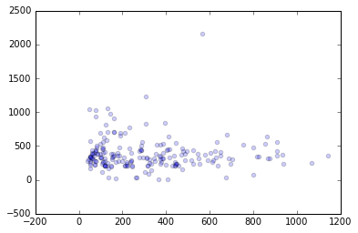

```
(97, 2)
```

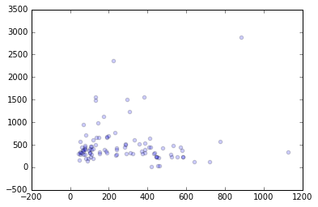

```python
%matplotlib inline
plt.clf()
tmp = test[(predictframe_nn1['author']>thresh[np.argmax(rec<0.80)])][['center_x','center_y']].as_matrix()
print(tmp.shape)
plt.scatter(tmp[:,0],tmp[:,1],alpha=0.2)
#plt.ylim(0,1000)
plt.show()

tmp = test[list(predictframe_nn1['label']==1)][['center_x','center_y']].as_matrix()
print(tmp.shape)
plt.scatter(tmp[:,0],tmp[:,1],alpha=0.2)
#plt.ylim(0,1000)
plt.show()
```

```python
prec, rec, thresh = precision_recall_curve(y_test==1, predictions_nn1[:,1])
tmp = raw_frame.loc[predictframe_nn1[(predictframe_nn1['plabel']==1)&(predictframe_nn1['label']!=1)&
                                     (predictframe_nn1['author']>thresh[np.argmax(rec<0.80)])].index]
tmp
```

```python
import re
cnts = []

for iinst, inst in  raw_framee.groupby('instance'):
    remove = r'[\.,\;\-\(\)&\'\"\%\:\\\|\/]'
    cnt = pd.Series(re.sub(r'\W+',' ', re.sub(remove,' '," ".join(list(inst['text'])).lower())).split(' ')).value_counts()

    for i, row in inst.iterrows():
        tc = 0
        for w in re.sub(r'\W+',' ', re.sub(remove,' ', row['text'].lower())).split(' '):
            if w in cnt.index and len(w)>1:
                tc = tc+cnt.loc[w]
        cnts.append({
                'label': row['label'],
                'score': tc,
                'inst': row['instance']
            })
cnt_frme = pd.DataFrame(cnts, index = raw_framee.index)
```

```python
import re
cnts = []

for iinst, inst in  raw_frame.groupby('instance'):
    remove = r'[\.,\;\-\(\)&\'\"\%\:\\\|\/]'
    cnt = pd.Series(re.sub(r'\W+',' ', re.sub(remove,' '," ".join(list(inst['text'])).lower())).split(' ')).value_counts()

    for i, row in inst.iterrows():
        tc = 0
        for w in re.sub(r'\W+',' ', re.sub(remove,' ', row['text'].lower())).split(' '):
            if w in cnt.index and len(w)>1:
                tc = tc+cnt.loc[w]
        cnts.append({
                'label': row['label'],
                'score': tc,
                'inst': row['instance']
            })
cnt_frm = pd.DataFrame(cnts, index = raw_frame.index)
```

```python
cnt_frm.groupby('label').describe()
```

### Test Author prediction fixes

```python
pss = pd.Series([3]*len(predictframe_nn1), index=predictframe_nn1.index)
pss.loc[predictframe_nn1[(ps==1)&(predictframe_nn1['author']>thresh[np.argmax(rec<0.60)])][['instance','author']].groupby('instance').idxmax()['author']] = 1

eva.measure_performance(None, y_test, list(pss))
```

```
Accuracy:0.981
             precision    recall  f1-score   support

      title       0.00      0.00      0.00       170
     author       0.33      0.34      0.33        97
       date       0.00      0.00      0.00        81
 unassigned       0.98      1.00      0.99     20087

avg / total       0.97      0.98      0.98     20435

[[    0     1     0   169]
 [    0    33     0    64]
 [    0     0     0    81]
 [    0    67     0 20020]]
```

```python
ps = pd.Series([3]*len(predictframe_nn1), index=predictframe_nn1.index)
prec, rec, thresh = precision_recall_curve(y_test==1, predictions_nn1[:,1])

thr = thresh[np.argmax(rec<0.60)]

for i, inst in predictframe_nn1[predictframe_nn1['author']>thresh[np.argmax(rec<0.90)]].groupby('instance'):
    #print(inst.shape)
    if inst.shape[0] > 1:
        for j in range(len(inst)-1):
            for k in range(j+1, len(inst)):
                a = feature_frame.loc[inst.iloc[j].name][['center_x','center_y']].as_matrix()
                b = feature_frame.loc[inst.iloc[k].name][['center_x','center_y']].as_matrix()
                if np.linalg.norm(a-b) < 250:
                    #if inst.iloc[j]['author'] > thr:
                    ps.loc[inst.iloc[j].name] = 1
                    #if inst.iloc[k]['author'] > thr:
                    ps.loc[inst.iloc[k].name] = 1
                else:
                    mx = np.argmax([inst.iloc[j]['author'], inst.iloc[k]['author']])
                    #if inst.iloc[[j,k][mx]]['author'] > thr:
                    ps.loc[[inst.iloc[j].name,inst.iloc[k].name][mx]] = 1
    else:
        #if inst.iloc[0]['author'] > thr:
        ps.loc[inst.iloc[0].name] = 1
eva.measure_performance(None, y_test, list(ps))
```

```
Accuracy:0.936
             precision    recall  f1-score   support

      title       0.00      0.00      0.00       170
     author       0.07      0.87      0.14        97
       date       0.00      0.00      0.00        81
 unassigned       0.99      0.95      0.97     20087

avg / total       0.97      0.94      0.95     20435

[[    0     1     0   169]
 [    0    84     0    13]
 [    0     0     0    81]
 [    0  1051     0 19036]]
```

## Analyse date predictions

```python
prec, rec, thresh = precision_recall_curve(y_test==1, predictions_nn1[:,1])
tmp = raw_frame.loc[predictframe_nn1[(predictframe_nn1['plabel']==2)&(predictframe_nn1['label']!=2)&
                                     (predictframe_nn1['author']>thresh[np.argmax(rec<0.80)])].index]
tmp
#raw_frame.loc[predictframe_nn1[predictframe_nn1['plabel']==2].index]
```

# RNN

```python
eva, keep_features, test, train, X_train, y_train, Y_train, X_test, y_test, Y_test, nb_classes, class_weights = eva_b_rnn
```

```python
from keras.models import Sequential
from keras.layers.core import Dense, Activation, Dropout
from keras.layers.wrappers import TimeDistributed
from keras.layers.recurrent import LSTM, SimpleRNN
from keras.callbacks import EarlyStopping, TensorBoard

from keras.layers.advanced_activations import LeakyReLU
from keras.regularizers import l2, activity_l2
from keras.utils import np_utils
import keras.optimizers as opts

nb_epoch = 20
batch_size = 20
val_data_size = 50

model_rnn = Sequential()

model_rnn.add(TimeDistributed(
            Dense(output_dim=len(keep_features),
                  input_dim=len(keep_features),
                  init='he_uniform',
                  activation='linear',
                  name='input_layer'
                 ),
            input_shape=(neighbourhood_size, len(keep_features)),
            name='dist_in_layer'))

model_rnn.add(SimpleRNN(70,
               return_sequences=True,
               activation='softsign',
               W_regularizer=l2(0.01),
               U_regularizer=l2(0.01),
               dropout_U=0.5,
               dropout_W=0.2,
               init='he_uniform',
               name='rnn_layer1'
              ))

model_rnn.add(SimpleRNN(40,
               return_sequences=False,
               activation='softsign',
               W_regularizer=l2(0.01),
               U_regularizer=l2(0.01),
               dropout_U=0.3,
               dropout_W=0.1,
               init='he_uniform',
               name='rnn_layer2'
              ))

model_rnn.add(Dense(nb_classes,
                init='he_uniform',
                activation='softmax',
                name='out_layer'))

model_rnn.summary()

print('compiling model...')
model_rnn.compile(loss='msle',
              optimizer=opts.Adadelta(),
              metrics=['accuracy'])

print('starting training...')
history = model_rnn.fit(X_train, Y_train,
                batch_size=batch_size, nb_epoch=nb_epoch,
                class_weight=class_weights,
                verbose=1,
                validation_data=(X_test[:val_data_size], Y_test[:val_data_size]))

print('done')
```

```
____________________________________________________________________________________________________
Layer (type)                     Output Shape          Param #     Connected to
====================================================================================================
dist_in_layer (TimeDistributed)  (None, 10, 149)       22350       timedistributed_input_2[0][0]
____________________________________________________________________________________________________
rnn_layer1 (SimpleRNN)           (None, 10, 70)        15400       dist_in_layer[0][0]
____________________________________________________________________________________________________
rnn_layer2 (SimpleRNN)           (None, 40)            4440        rnn_layer1[0][0]
____________________________________________________________________________________________________
out_layer (Dense)                (None, 4)             164         rnn_layer2[0][0]
====================================================================================================
Total params: 42354
____________________________________________________________________________________________________
compiling model...
starting training...
Train on 48585 samples, validate on 50 samples
```

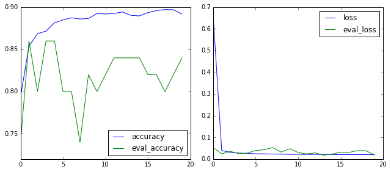

```
raw
Accuracy:0.929
             precision    recall  f1-score   support

      title       0.28      0.99      0.43       204
     author       0.11      0.86      0.19       144
       date       0.30      0.88      0.44       110
 unassigned       1.00      0.93      0.96     25201

avg / total       0.98      0.93      0.95     25659

[[  202     0     0     2]
 [    3   124     2    15]
 [    0     0    97    13]
 [  522  1049   228 23402]]
```

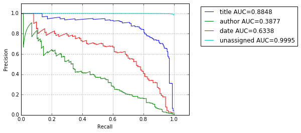

```
idxmax
Accuracy:0.985
             precision    recall  f1-score   support

      title       0.90      0.90      0.90       204
     author       0.33      0.46      0.38       144
       date       0.43      0.79      0.55       110
 unassigned       1.00      0.99      0.99     25201

avg / total       0.99      0.98      0.99     25659

[[  184     0     0    20]
 [    0    66     2    76]
 [    0     0    87    23]
 [   20   133   115 24933]]
plabel idxmax
Accuracy:0.988
             precision    recall  f1-score   support

      title       0.90      0.90      0.90       204
     author       0.34      0.45      0.39       144
       date       0.65      0.76      0.70       110
 unassigned       1.00      0.99      0.99     25201

avg / total       0.99      0.99      0.99     25659

[[  184     0     0    20]
 [    0    65     2    77]
 [    0     0    84    26]
 [   20   125    44 25012]]
```

```python
%matplotlib inline

eva.draw_traingraph(history)

predictions_rnn = model_rnn.predict_proba(X_test)
predictframe_rnn = eva.get_predictframe(predictions_rnn, global_idxmax=True, plabel_idxmax=True)

print('raw')
eva.measure_performance(None, y_test, predictions_rnn, show_curves=True)
print('idxmax')
eva.measure_performance(None, y_test, list(predictframe_rnn['gilabel']))
print('plabel idxmax')
eva.measure_performance(None, y_test, list(predictframe_rnn['ilabel']))
```

```python
from sklearn.metrics import precision_recall_curve
ps = pd.Series([3]*len(predictframe_rnn), index=predictframe_rnn.index)

prec, rec, thresh = precision_recall_curve(y_test==0, predictions_rnn[:,0])
ps.loc[predictframe_rnn['title']>thresh[np.argmax(prec>0.8)]] = 0

prec, rec, thresh = precision_recall_curve(y_test==1, predictions_rnn[:,1])
ps.loc[predictframe_rnn['author']>thresh[np.argmax(rec<0.6)]] = 1

prec, rec, thresh = precision_recall_curve(y_test==2, predictions_rnn[:,2])
ps.loc[predictframe_rnn['issued']>thresh[np.argmax(prec>0.6)]] = 2

eva.measure_performance(None, y_test, list(ps))
```

```
Accuracy:0.983
             precision    recall  f1-score   support

      title       0.80      0.81      0.81       204
     author       0.28      0.60      0.38       144
       date       0.61      0.68      0.64       110
 unassigned       0.99      0.99      0.99     25201

avg / total       0.99      0.98      0.98     25659

[[  165     0     0    39]
 [    0    86     2    56]
 [    0     0    75    35]
 [   40   218    46 24897]]
```

```python
from sklearn.metrics import precision_recall_curve
ps = pd.Series([3]*len(predictframe_rnn), index=predictframe_rnn.index)

prec, rec, thresh = precision_recall_curve(y_test==0, predictions_rnn[:,0])
ps.loc[predictframe_rnn['title']>thresh[np.argmax(prec>0.8)]] = 0

prec, rec, thresh = precision_recall_curve(y_test==1, predictions_rnn[:,1])
r = 0.72
tmp = raw_frame.loc[predictframe_rnn[(predictframe_rnn['plabel']==1)&
                                     (predictframe_rnn['author']>thresh[np.argmax(rec<r)])].index]
cnt_frm_ = cnt_frm.loc[predictframe_rnn[(predictframe_rnn['plabel']==1)&
                                     (predictframe_rnn['author']>thresh[np.argmax(rec<r)])].index]
print(len(cnt_frm_))
print(tmp.shape)
ps.loc[predictframe_rnn[
       (predictframe_rnn['plabel']==1)&
       (predictframe_rnn['author']>thresh[np.argmax(rec<r)])&
       (feature_frame['num_words']>1)&
       (~tmp['text'].str.contains('sign',case=False))&
       (~tmp['text'].str.contains('more',case=False))&
       (~tmp['text'].str.contains('share',case=False))&
       (~tmp['text'].str.contains('contact',case=False))&
       (~tmp['text'].str.contains('news',case=False))&
       (~tmp['text'].str.contains('the ',case=False))&
       (~tmp['text'].str.contains('about ',case=False))&
       (cnt_frm_['score']<30)].index
      ] = 1
print(ps[ps==1].shape)

prec, rec, thresh = precision_recall_curve(y_test==2, predictions_rnn[:,2])
ps.loc[(~raw_frame['text'].str.contains(r'\d{4}.+?\d{4}'))&
       (~raw_frame['text'].str.contains(r'(?:^|\D)\d{3}(?:\D|$)'))&
       (predictframe_rnn['issued']>thresh[np.argmax(rec<0.75)])] = 2

eva.measure_performance(None, y_test, list(ps))
```

```
520
(520, 44)
(315,)
Accuracy:0.983
             precision    recall  f1-score   support

      title       0.80      0.81      0.81       204
     author       0.30      0.65      0.41       144
       date       0.56      0.72      0.63       110
 unassigned       1.00      0.99      0.99     25201

avg / total       0.99      0.98      0.99     25659

[[  165     0     0    39]
 [    0    94     2    48]
 [    0     0    79    31]
 [   40   221    59 24881]]
```

```python
from sklearn.metrics import precision_recall_curve
ps = pd.Series([3]*len(predictframe_rnn), index=predictframe_rnn.index)

prec, rec, thresh = precision_recall_curve(y_test==0, predictions_rnn[:,0])
f1 = np.nan_to_num((2*(prec*rec)/(prec+rec)))
bestf1 = f1.argmax()

ps.loc[predictframe_rnn[(predictframe_rnn['plabel']==0)&
                        (predictframe_rnn['title']>=thresh[bestf1]-0.1) #np.argmax(rec<0.99)
                       ].groupby('instance').idxmax()['title']] = 0

prec, rec, thresh = precision_recall_curve(y_test==1, predictions_rnn[:,1])
f1 = np.nan_to_num((2*(prec*rec)/(prec+rec)))
bestf1 = f1.argmax()
r = thresh[bestf1]-0.1 #0.72
tmp = raw_frame.loc[predictframe_rnn[(predictframe_rnn['plabel']==1)&
                                     (predictframe_rnn['author']>r)].index]
cnt_frm_ = cnt_frm.loc[predictframe_rnn[(predictframe_rnn['plabel']==1)&
                                     (predictframe_rnn['author']>r)].index]

ps.loc[predictframe_rnn[(predictframe_rnn['plabel']==1)&
                        (predictframe_rnn['author']>r)&
                        (~tmp['text'].str.contains('sign',case=False))&
                        (~tmp['text'].str.contains('more',case=False))&
                        (~tmp['text'].str.contains('share',case=False))&
                        (~tmp['text'].str.contains('contact',case=False))&
                        (~tmp['text'].str.contains('news',case=False))&
                        (~tmp['text'].str.contains('the ',case=False))&
                        (~tmp['text'].str.contains('about ',case=False))
                       ].groupby('instance').idxmax()['author']] = 1

prec, rec, thresh = precision_recall_curve(y_test==2, predictions_rnn[:,2])
f1 = np.nan_to_num((2*(prec*rec)/(prec+rec)))
bestf1 = f1.argmax()

ps.loc[predictframe_rnn[(predictframe_rnn['plabel']==2)&
                        (~raw_frame['text'].str.contains(r'\d{4}.+?\d{4}'))&
                        (~raw_frame['text'].str.contains(r'(?:^|\D)\d{3}(?:\D|$)'))&
                        (predictframe_rnn['issued']>thresh[bestf1]-0.05)
                       ].groupby('instance').idxmax()['issued']] = 2

eva.measure_performance(None, y_test, list(ps))
```

```
Accuracy:0.990
             precision    recall  f1-score   support

      title       0.90      0.89      0.89       204
     author       0.48      0.42      0.45       144
       date       0.81      0.65      0.72       110
 unassigned       0.99      1.00      1.00     25201

avg / total       0.99      0.99      0.99     25659

[[  181     0     0    23]
 [    0    60     2    82]
 [    0     0    71    39]
 [   20    65    15 25101]]
```

```python
from sklearn.metrics import precision_recall_curve
ps = pd.Series([3]*len(predictframe_rnn), index=predictframe_rnn.index)

prec, rec, thresh = precision_recall_curve(y_test==0, predictions_rnn[:,0])
ps.loc[predictframe_rnn[(predictframe_rnn['plabel']==0)&(predictframe_rnn['title']>thresh[np.argmax(rec<0.99)])].groupby('instance').idxmax()['title']] = 0

prec, rec, thresh = precision_recall_curve(y_test==1, predictions_rnn[:,1])
ps.loc[predictframe_rnn[(predictframe_rnn['plabel']==1)&(predictframe_rnn['author']>thresh[np.argmax(rec<0.65)])].groupby('instance').idxmax()['author']] = 1

prec, rec, thresh = precision_recall_curve(y_test==2, predictions_rnn[:,2])
ps.loc[predictframe_rnn[(predictframe_rnn['plabel']==2)&(predictframe_rnn['issued']>thresh[np.argmax(rec<0.75)])].groupby('instance').idxmax()['issued']] = 2

eva.measure_performance(None, y_test, list(ps))
```

```
Accuracy:0.990
             precision    recall  f1-score   support

      title       0.90      0.90      0.90       204
     author       0.41      0.40      0.40       144
       date       0.77      0.68      0.72       110
 unassigned       0.99      1.00      0.99     25201

avg / total       0.99      0.99      0.99     25659

[[  184     0     0    20]
 [    0    57     2    85]
 [    0     0    75    35]
 [   20    81    20 25080]]
```

# Random Forest

```python
eva, keep_features, test, train, X_train, y_train, Y_train, X_test, y_test, Y_test, nb_classes, class_weights = eva_b_rf
```

```python
from sklearn.multiclass import OneVsRestClassifier
from sklearn.ensemble import BaggingClassifier, RandomForestClassifier
import warnings

forest = RandomForestClassifier(class_weight='balanced', criterion='entropy', n_estimators=400, n_jobs=50)
bag = BaggingClassifier(forest, n_estimators=20, max_features=0.7, n_jobs=1)
clf = OneVsRestClassifier(bag, n_jobs=1)

with warnings.catch_warnings():
    warnings.simplefilter('ignore', DeprecationWarning)
    clf.fit(X_train, y_train)
    predictions_rf = clf.predict_proba(X_test)
```

```
raw
Accuracy:0.992
             precision    recall  f1-score   support

      title       0.89      0.84      0.86       204
     author       0.94      0.25      0.39       124
       date       0.86      0.54      0.67       103
 unassigned       0.99      1.00      1.00     24180

avg / total       0.99      0.99      0.99     24611

[[  171     0     0    33]
 [    0    31     1    92]
 [    0     0    56    47]
 [   21     2     8 24149]]
```

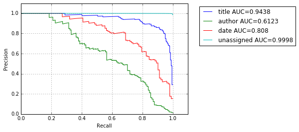

```
idxmax
Accuracy:0.986
             precision    recall  f1-score   support

      title       0.90      0.89      0.89       204
     author       0.32      0.49      0.39       124
       date       0.45      0.89      0.60       103
 unassigned       1.00      0.99      0.99     24180

avg / total       0.99      0.99      0.99     24611

[[  182     1     1    20]
 [    0    61    10    53]
 [    0     0    92    11]
 [   21   127   101 23931]]
plabel idxmax
Accuracy:0.992
             precision    recall  f1-score   support

      title       0.93      0.82      0.87       204
     author       0.96      0.22      0.36       124
       date       0.93      0.54      0.69       103
 unassigned       0.99      1.00      1.00     24180

avg / total       0.99      0.99      0.99     24611

[[  167     0     0    37]
 [    0    27     1    96]
 [    0     0    56    47]
 [   13     1     3 24163]]
```

```python
%matplotlib inline

predictframe_rf = eva.get_predictframe(predictions_rf, global_idxmax=True, plabel_idxmax=True)

print('raw')
eva.measure_performance(None, y_test, predictions_rf, show_curves=True)
print('idxmax')
eva.measure_performance(None, y_test, list(predictframe_rf['gilabel']))
print('plabel idxmax')
eva.measure_performance(None, y_test, list(predictframe_rf['ilabel']))
```

```python
from sklearn.metrics import precision_recall_curve
ps = pd.Series([3]*len(predictframe_rf), index=predictframe_rf.index)

prec, rec, thresh = precision_recall_curve(y_test==0, predictions_rf[:,0])
ps.loc[predictframe_rf['title']>thresh[np.argmax(prec>0.85)]] = 0

prec, rec, thresh = precision_recall_curve(y_test==1, predictions_rf[:,1])
ps.loc[predictframe_rf['author']>thresh[np.argmax(rec<0.6)]] = 1

prec, rec, thresh = precision_recall_curve(y_test==2, predictions_rf[:,2])
ps.loc[predictframe_rf['issued']>thresh[np.argmax(rec<0.75)]] = 2

eva.measure_performance(None, y_test, list(ps))
```

```
Accuracy:0.992
             precision    recall  f1-score   support

      title       0.85      0.91      0.88       204
     author       0.62      0.60      0.61       144
       date       0.75      0.75      0.75       110
 unassigned       1.00      1.00      1.00     25201

avg / total       0.99      0.99      0.99     25659

[[  186     0     0    18]
 [    0    86     1    57]
 [    0     0    82    28]
 [   32    53    26 25090]]
```

```python
from sklearn.metrics import precision_recall_curve
ps = pd.Series([3]*len(predictframe_rf), index=predictframe_rf.index)

prec, rec, thresh = precision_recall_curve(y_test==0, predictions_rf[:,0])
ps.loc[predictframe_rf['title']>thresh[np.argmax(prec>0.85)]] = 0

prec, rec, thresh = precision_recall_curve(y_test==1, predictions_rf[:,1])
r = 0.75
tmp = raw_frame.loc[predictframe_rf[#(predictframe_rf['plabel']==1)&
                                     (predictframe_rf['author']>thresh[np.argmax(rec<r)])].index]
cnt_frm_ = cnt_frm.loc[predictframe_rf[#(predictframe_rf['plabel']==1)&
                                     (predictframe_rf['author']>thresh[np.argmax(rec<r)])].index]
print(len(cnt_frm_))
print(tmp.shape)
ps.loc[predictframe_rf[
       #(predictframe_rf['plabel']==1)&
       (predictframe_rf['author']>thresh[np.argmax(rec<r)])&
       #(feature_frame['num_words']>1)&
       (~tmp['text'].str.contains('sign',case=False))&
       (~tmp['text'].str.contains('more',case=False))&
       (~tmp['text'].str.contains('share',case=False))&
       (~tmp['text'].str.contains('contact',case=False))&
       (~tmp['text'].str.contains('news',case=False))&
       (~tmp['text'].str.contains('the ',case=False))&
       (~tmp['text'].str.contains('about ',case=False))&
       (cnt_frm_['score']<35)].index
      ] = 1
print(ps[ps==1].shape)

prec, rec, thresh = precision_recall_curve(y_test==2, predictions_rf[:,2])
ps.loc[(~raw_frame['text'].str.contains(r'\d{4}.+?\d{4}'))&
       (~raw_frame['text'].str.contains(r'(?:^|\D)\d{3}(?:\D|$)'))&
       (predictframe_rf['issued']>thresh[np.argmax(rec<0.8)])] = 2

eva.measure_performance(None, y_test, list(ps))
```

```
250
(250, 44)
(197,)
Accuracy:0.990
             precision    recall  f1-score   support

      title       0.85      0.91      0.88       204
     author       0.50      0.68      0.57       144
       date       0.69      0.75      0.72       110
 unassigned       1.00      0.99      0.99     25201

avg / total       0.99      0.99      0.99     25659

[[  186     0     0    18]
 [    0    98     1    45]
 [    0     0    83    27]
 [   32    99    37 25033]]
```

```python
from sklearn.metrics import precision_recall_curve
ps = pd.Series([3]*len(predictframe_rf), index=predictframe_rf.index)

prec, rec, thresh = precision_recall_curve(y_test==0, predictions_rf[:,0])
ps.loc[predictframe_rf[(predictframe_rf['plabel']==0)&(predictframe_rf['title']>thresh[np.argmax(rec<0.99)])].groupby('instance').idxmax()['title']] = 0

prec, rec, thresh = precision_recall_curve(y_test==1, predictions_rf[:,1])
ps.loc[predictframe_rf[(predictframe_rf['plabel']==1)&(predictframe_rf['author']>thresh[np.argmax(rec<0.65)])].groupby('instance').idxmax()['author']] = 1

prec, rec, thresh = precision_recall_curve(y_test==2, predictions_rf[:,2])
ps.loc[predictframe_rf[(predictframe_rf['plabel']==2)&(predictframe_rf['issued']>thresh[np.argmax(rec<0.9)])].groupby('instance').idxmax()['issued']] = 2

eva.measure_performance(None, y_test, list(ps))
```

```
Accuracy:0.991
             precision    recall  f1-score   support

      title       0.92      0.84      0.88       204
     author       1.00      0.16      0.28       144
       date       0.95      0.52      0.67       110
 unassigned       0.99      1.00      1.00     25201

avg / total       0.99      0.99      0.99     25659

[[  171     0     0    33]
 [    0    23     1   120]
 [    0     0    57    53]
 [   15     0     2 25184]]
```

# RF merged with Simple NN

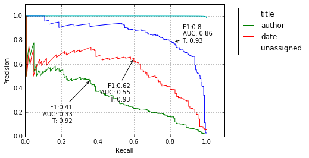

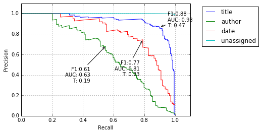

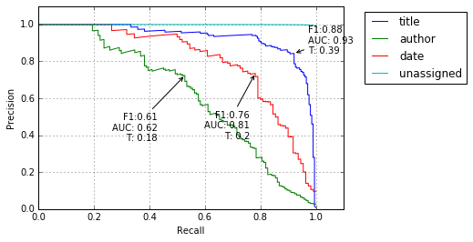

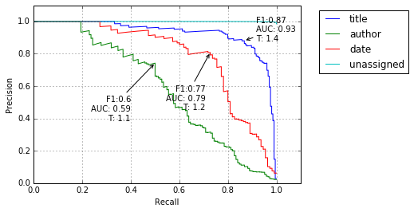

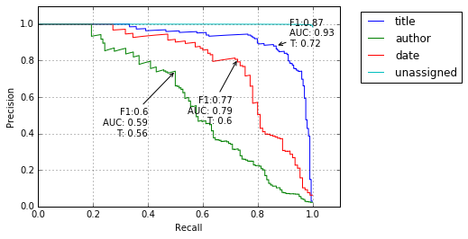

```python
pr_curve(y_test, np.maximum(predictions_nn1,predictions_rf))
pr_curve(y_test, np.minimum(predictions_nn1,predictions_rf))
pr_curve(y_test, (predictions_nn1*predictions_rf))
pr_curve(y_test, (predictions_nn1+predictions_rf))
pr_curve(y_test, (predictions_nn1+predictions_rf)/2)
```

```
NN
Accuracy:0.892
             precision    recall  f1-score   support

      title       0.28      0.99      0.44       204
     author       0.07      0.90      0.12       144
       date       0.19      0.94      0.32       110
 unassigned       1.00      0.89      0.94     25201

avg / total       0.98      0.89      0.93     25659

[[  202     0     0     2]
 [    3   130     2     9]
 [    0     0   103     7]
 [  511  1814   432 22444]]
```

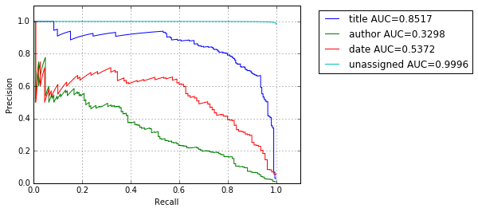

```
tree
Accuracy:0.991
             precision    recall  f1-score   support

      title       0.88      0.87      0.87       204
     author       1.00      0.17      0.30       144
       date       0.91      0.53      0.67       110
 unassigned       0.99      1.00      1.00     25201

avg / total       0.99      0.99      0.99     25659

[[  178     0     0    26]
 [    0    25     1   118]
 [    0     0    58    52]
 [   25     0     5 25171]]
```

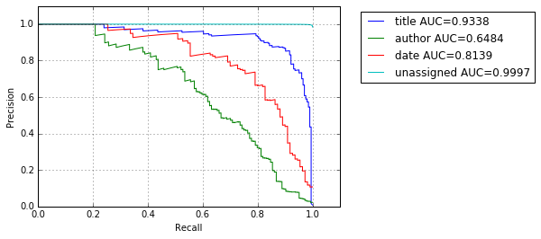

```
min
Accuracy:0.974
             precision    recall  f1-score   support

      title       0.54      0.98      0.70       204
     author       0.27      0.74      0.40       144
       date       0.38      0.85      0.52       110
 unassigned       1.00      0.98      0.99     25201

avg / total       0.99      0.97      0.98     25659

[[  199     0     0     5]
 [    3   107     2    32]
 [    0     0    93    17]
 [  166   287   152 24596]]
```

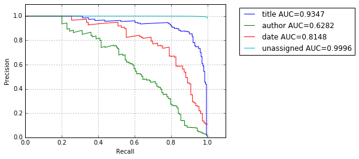

```
max
Accuracy:0.983
             precision    recall  f1-score   support

      title       0.63      0.97      0.77       204
     author       0.40      0.63      0.49       144
       date       0.44      0.82      0.58       110
 unassigned       1.00      0.99      0.99     25201

avg / total       0.99      0.98      0.98     25659

[[  198     0     0     6]
 [    2    91     2    49]
 [    0     0    90    20]
 [  113   135   111 24842]]
```

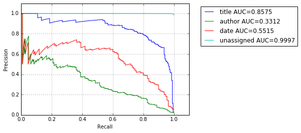

```
mult
Accuracy:0.976
             precision    recall  f1-score   support

      title       0.55      0.98      0.71       204
     author       0.29      0.74      0.41       144
       date       0.39      0.85      0.53       110
 unassigned       1.00      0.98      0.99     25201

avg / total       0.99      0.98      0.98     25659

[[  199     0     0     5]
 [    3   106     2    33]
 [    0     0    93    17]
 [  158   262   143 24638]]
```

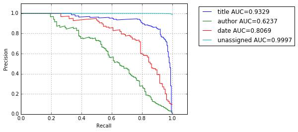

```
add
Accuracy:0.980
             precision    recall  f1-score   support

      title       0.59      0.97      0.73       204
     author       0.35      0.66      0.46       144
       date       0.41      0.83      0.55       110
 unassigned       1.00      0.98      0.99     25201

avg / total       0.99      0.98      0.98     25659

[[  198     0     0     6]
 [    3    95     2    44]
 [    0     0    91    19]
 [  134   176   130 24761]]
```

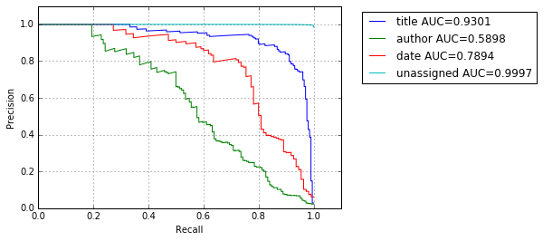

```
avg
Accuracy:0.980
             precision    recall  f1-score   support

      title       0.59      0.97      0.73       204
     author       0.35      0.66      0.46       144
       date       0.41      0.83      0.55       110
 unassigned       1.00      0.98      0.99     25201

avg / total       0.99      0.98      0.98     25659

[[  198     0     0     6]
 [    3    95     2    44]
 [    0     0    91    19]
 [  134   176   130 24761]]
```

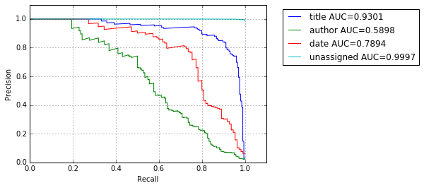

```python
print('NN')
eva.measure_performance(None, y_test, predictions_nn1, show_curves=True)
print('tree')
eva.measure_performance(None, y_test, predictions_rf, show_curves=True)
print('min')
eva.measure_performance(None, y_test, np.minimum(predictions_nn1,predictions_rf), show_curves=True)
print('max')
eva.measure_performance(None, y_test, np.maximum(predictions_nn1,predictions_rf), show_curves=True)
print('mult')
eva.measure_performance(None, y_test, (predictions_nn1*predictions_rf), show_curves=True)
print('add')
eva.measure_performance(None, y_test, (predictions_nn1+predictions_rf), show_curves=True)
print('avg')
eva.measure_performance(None, y_test, (predictions_nn1+predictions_rf)/2, show_curves=True)
```

```python
predictframe_merge = eva.get_predictframe((predictions_nn1+predictions_rf)/2, global_idxmax=True, plabel_idxmax=True)
predictions_merge = predictframe_merge[['title','author','issued','unassigned']].as_matrix()
print('idxmax')
eva.measure_performance(None, y_test, list(predictframe_merge['gilabel']))
print('plabel idxmax')
eva.measure_performance(None, y_test, list(predictframe_merge['ilabel']))
```

```
idxmax
Accuracy:0.986
             precision    recall  f1-score   support

      title       0.91      0.91      0.91       204
     author       0.39      0.54      0.45       144
       date       0.44      0.82      0.57       110
 unassigned       1.00      0.99      0.99     25201

avg / total       0.99      0.99      0.99     25659

[[  185     0     0    19]
 [    0    78     2    64]
 [    0     0    90    20]
 [   19   124   112 24946]]
plabel idxmax
Accuracy:0.991
             precision    recall  f1-score   support

      title       0.91      0.90      0.90       204
     author       0.56      0.47      0.51       144
       date       0.74      0.75      0.74       110
 unassigned       1.00      1.00      1.00     25201

avg / total       0.99      0.99      0.99     25659

[[  183     0     0    21]
 [    0    68     2    74]
 [    0     0    82    28]
 [   19    54    27 25101]]
```

```python
from sklearn.metrics import precision_recall_curve
ps = pd.Series([3]*len(predictframe_merge), index=predictframe_merge.index)

prec, rec, thresh = precision_recall_curve(y_test==0, predictions_merge[:,0])
ps.loc[predictframe_merge['title']>thresh[np.argmax(prec>0.85)]] = 0

prec, rec, thresh = precision_recall_curve(y_test==1, predictions_merge[:,1])
f1 = (2*(prec*rec)/(prec+rec))
bestf1 = f1.argmax()
t = thresh[f1.argmax()]-0.05
r = 0.7
tmp = raw_frame.loc[predictframe_merge[#(predictframe_merge['plabel']==1)&
                                       #(predictframe_merge['author']>thresh[np.argmax(rec<r)])
                                       (predictframe_merge['author']>t)].index]
cnt_frm_ = cnt_frm.loc[predictframe_merge[#(predictframe_merge['plabel']==1)&
                                       #(predictframe_merge['author']>thresh[np.argmax(rec<r)])
                                       (predictframe_merge['author']>t)].index]
print(len(cnt_frm_))
print(tmp.shape)
ps.loc[predictframe_merge[
       #(predictframe_merge['plabel']==1)&
       #(predictframe_merge['author']>thresh[np.argmax(rec<r)])&
       (predictframe_merge['author']>t-0.1)&
       #(feature_frame['num_words']>1)&
       #(~tmp['text'].str.contains('sign',case=False))&
       #(~tmp['text'].str.contains('more',case=False))&
       #(~tmp['text'].str.contains('share',case=False))&
       #(~tmp['text'].str.contains('contact',case=False))&
       #(~tmp['text'].str.contains('news',case=False))&
       #(~tmp['text'].str.contains('the ',case=False))&
       #(~tmp['text'].str.contains('about ',case=False))&
       (cnt_frm_['score']<40)].index
      ] = 1
print(ps[ps==1].shape)

prec, rec, thresh = precision_recall_curve(y_test==2, predictions_merge[:,2])
ps.loc[(~raw_frame['text'].str.contains(r'\d{4}.+?\d{4}'))&
       (~raw_frame['text'].str.contains(r'(?:^|\D)\d{3}(?:\D|$)'))&
       (predictframe_merge['issued']>thresh[np.argmax(rec<0.78)])] = 2
predictframe_merge['tf'] = ps
eva.measure_performance(None, y_test, list(ps))
```

```
190
(190, 44)
(170,)
Accuracy:0.990
             precision    recall  f1-score   support

      title       0.85      0.89      0.87       204
     author       0.49      0.58      0.53       144
       date       0.70      0.74      0.72       110
 unassigned       1.00      0.99      0.99     25201

avg / total       0.99      0.99      0.99     25659

[[  182     0     0    22]
 [    0    83     1    60]
 [    0     0    81    29]
 [   32    87    33 25049]]
```

```python
from sklearn.metrics import precision_recall_curve
ps = pd.Series([3]*len(predictframe_merge), index=predictframe_merge.index)

prec, rec, thresh = precision_recall_curve(y_test==0, predictions_merge[:,0])
f1 = (2*(prec*rec)/(prec+rec))
bestf1 = f1.argmax()
t = thresh[f1.argmax()]
ps.loc[predictframe_merge['title']>t] = 0

prec, rec, thresh = precision_recall_curve(y_test==1, predictions_merge[:,1])
f1 = (2*(prec*rec)/(prec+rec))
bestf1 = f1.argmax()
t = thresh[f1.argmax()]
ps.loc[predictframe_merge['author']>t] = 1

prec, rec, thresh = precision_recall_curve(y_test==2, predictions_merge[:,2])
f1 = (2*(prec*rec)/(prec+rec))
bestf1 = f1.argmax()
t = thresh[f1.argmax()]
ps.loc[predictframe_merge['issued']>t] = 2

eva.measure_performance(None, y_test, list(ps))
```

```
Accuracy:0.992
             precision    recall  f1-score   support

      title       0.88      0.86      0.87       204
     author       0.74      0.49      0.59       144
       date       0.81      0.72      0.76       110
 unassigned       0.99      1.00      1.00     25201

avg / total       0.99      0.99      0.99     25659

[[  176     0     0    28]
 [    0    71     1    72]
 [    0     0    79    31]
 [   24    25    18 25134]]
```

```python
from sklearn.metrics import precision_recall_curve
ps = pd.Series([3]*len(predictframe_merge), index=predictframe_merge.index)

prec, rec, thresh = precision_recall_curve(y_test==0, predictions_merge[:,0])
f1 = (2*(prec*rec)/(prec+rec))
bestf1 = f1.argmax()
t = thresh[f1.argmax()]-0.1
print(t)
ps.loc[predictframe_merge[(predictframe_merge['plabel']==0)&
                          #(predictframe_merge['title']>thresh[np.argmax(rec<0.98)])
                          (predictframe_merge['title']>t)
                         ].groupby('instance').idxmax()['title']] = 0

prec, rec, thresh = precision_recall_curve(y_test==1, predictions_merge[:,1])
f1 = (2*(prec*rec)/(prec+rec))
bestf1 = f1.argmax()
t = thresh[f1.argmax()]
print(t)
ps.loc[predictframe_merge[(predictframe_merge['author']>t-0.05)&
                          #(predictframe_merge['author']>thresh[np.argmax(rec<0.7)])
                          #(predictframe_merge['plabel']==1)&
                          #(~tmp['text'].str.contains('sign',case=False))&
                          #(~tmp['text'].str.contains('more',case=False))&
                          #(~tmp['text'].str.contains('share',case=False))&
                          #(~tmp['text'].str.contains('contact',case=False))&
                          #(~tmp['text'].str.contains('news',case=False))&
                          #(~tmp['text'].str.contains('the ',case=False))&
                          #(~tmp['text'].str.contains('about ',case=False))&
                          (cnt_frm_['score']<50)
                         ].groupby('instance').idxmax()['author']] = 1

prec, rec, thresh = precision_recall_curve(y_test==2, predictions_merge[:,2])
f1 = (2*(prec*rec)/(prec+rec))
bestf1 = f1.argmax()
t = thresh[f1.argmax()]
print(t)
ps.loc[predictframe_merge[(predictframe_merge['plabel']==2)&
                          #(predictframe_merge['issued']>thresh[np.argmax(rec<0.8)])
                          (~raw_frame['text'].str.contains(r'\d{4}.+?\d{4}'))&
                          (~raw_frame['text'].str.contains(r'(?:^|\D)\d{3}(?:\D|$)'))&
                          (predictframe_merge['issued']>t)
                         ].groupby('instance').idxmax()['issued']] = 2
predictframe_merge['tfx'] = ps
eva.measure_performance(None, y_test, list(ps))
```

```
0.618803648253
0.562859420387
0.60414767182
Accuracy:0.992
             precision    recall  f1-score   support

      title       0.91      0.88      0.89       204
     author       0.65      0.42      0.51       144
       date       0.90      0.65      0.76       110
 unassigned       0.99      1.00      1.00     25201

avg / total       0.99      0.99      0.99     25659

[[  179     0     0    25]
 [    0    60     1    83]
 [    0     0    72    38]
 [   18    32     7 25144]]
```

# RF merged with RNN

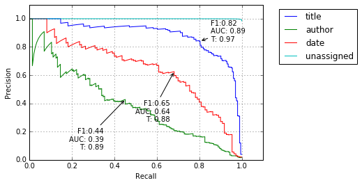

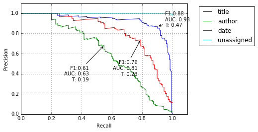

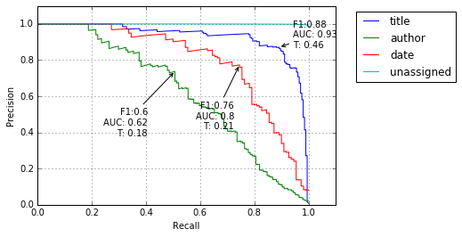

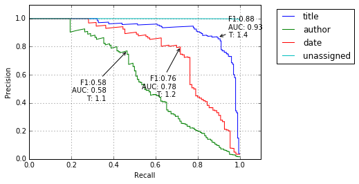

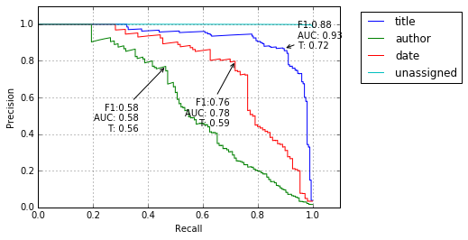

```python
pr_curve(y_test, np.maximum(predictions_rnn,predictions_rf))
pr_curve(y_test, np.minimum(predictions_rnn,predictions_rf))
pr_curve(y_test, (predictions_rnn*predictions_rf))
pr_curve(y_test, (predictions_rnn+predictions_rf))
pr_curve(y_test, (predictions_rnn+predictions_rf)/2)
```

```
NN
Accuracy:0.929
             precision    recall  f1-score   support

      title       0.28      0.99      0.43       204
     author       0.11      0.86      0.19       144
       date       0.30      0.88      0.44       110
 unassigned       1.00      0.93      0.96     25201

avg / total       0.98      0.93      0.95     25659

[[  202     0     0     2]
 [    3   124     2    15]
 [    0     0    97    13]
 [  522  1049   228 23402]]
```

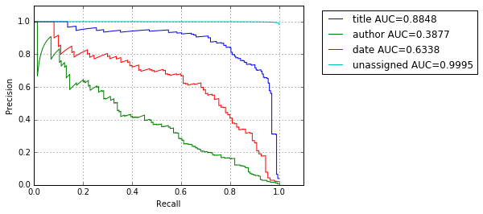

```
tree
Accuracy:0.991
             precision    recall  f1-score   support

      title       0.88      0.87      0.87       204
     author       1.00      0.17      0.30       144
       date       0.91      0.53      0.67       110
 unassigned       0.99      1.00      1.00     25201

avg / total       0.99      0.99      0.99     25659

[[  178     0     0    26]
 [    0    25     1   118]
 [    0     0    58    52]
 [   25     0     5 25171]]
```

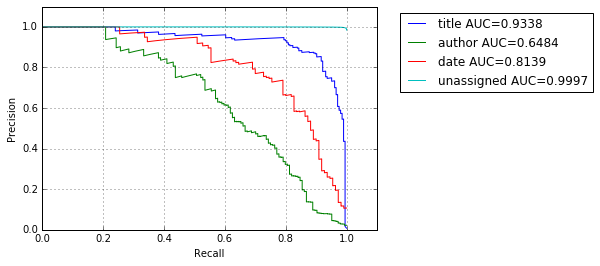

```
min
Accuracy:0.978
             precision    recall  f1-score   support

      title       0.52      0.98      0.68       204
     author       0.31      0.67      0.42       144
       date       0.49      0.77      0.60       110
 unassigned       1.00      0.98      0.99     25201

avg / total       0.99      0.98      0.98     25659

[[  200     0     0     4]
 [    3    96     2    43]
 [    0     0    85    25]
 [  181   216    88 24716]]
```

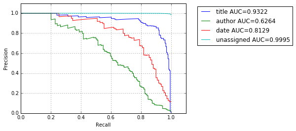

```
max
Accuracy:0.985
             precision    recall  f1-score   support

      title       0.58      0.98      0.73       204
     author       0.47      0.58      0.52       144
       date       0.59      0.76      0.67       110
 unassigned       1.00      0.99      0.99     25201

avg / total       0.99      0.99      0.99     25659

[[  199     0     0     5]
 [    3    83     2    56]
 [    0     0    84    26]
 [  141    92    56 24912]]
```

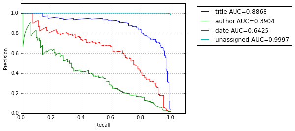

```
mult
Accuracy:0.979
             precision    recall  f1-score   support

      title       0.52      0.98      0.68       204
     author       0.34      0.66      0.45       144
       date       0.50      0.77      0.60       110
 unassigned       1.00      0.98      0.99     25201

avg / total       0.99      0.98      0.98     25659

[[  200     0     0     4]
 [    3    95     2    44]
 [    0     0    85    25]
 [  180   186    84 24751]]
```

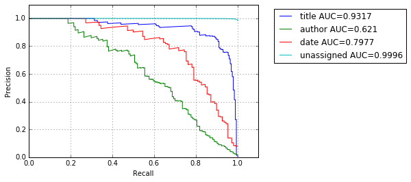

```
add
Accuracy:0.983
             precision    recall  f1-score   support

      title       0.56      0.98      0.72       204
     author       0.42      0.62      0.50       144
       date       0.55      0.76      0.64       110
 unassigned       1.00      0.99      0.99     25201

avg / total       0.99      0.98      0.99     25659

[[  200     0     0     4]
 [    3    89     2    50]
 [    0     0    84    26]
 [  152   121    67 24861]]
```

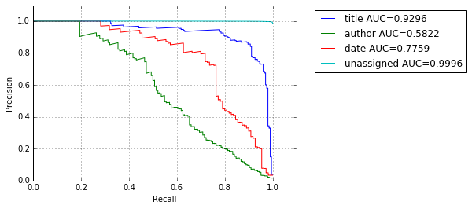

```
avg
Accuracy:0.983
             precision    recall  f1-score   support

      title       0.56      0.98      0.72       204
     author       0.42      0.62      0.50       144
       date       0.55      0.76      0.64       110
 unassigned       1.00      0.99      0.99     25201

avg / total       0.99      0.98      0.99     25659

[[  200     0     0     4]
 [    3    89     2    50]
 [    0     0    84    26]
 [  152   121    67 24861]]
```

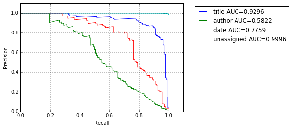

```python
print('NN')
eva.measure_performance(None, y_test, predictions_rnn, show_curves=True)
print('tree')
eva.measure_performance(None, y_test, predictions_rf, show_curves=True)
print('min')
eva.measure_performance(None, y_test, np.minimum(predictions_rnn,predictions_rf), show_curves=True)
print('max')
eva.measure_performance(None, y_test, np.maximum(predictions_rnn,predictions_rf), show_curves=True)
print('mult')
eva.measure_performance(None, y_test, (predictions_rnn*predictions_rf), show_curves=True)
print('add')
eva.measure_performance(None, y_test, (predictions_rnn+predictions_rf), show_curves=True)
print('avg')
eva.measure_performance(None, y_test, (predictions_rnn+predictions_rf)/2, show_curves=True)
```

```python
predictframe_merge3 = eva.get_predictframe((predictions_rnn+predictions_rf)/2, global_idxmax=True, plabel_idxmax=True)
predictions_merge3 = predictframe_merge3[['title','author','issued','unassigned']].as_matrix()
print('idxmax')
eva.measure_performance(None, y_test, list(predictframe_merge3['gilabel']))
print('plabel idxmax')
eva.measure_performance(None, y_test, list(predictframe_merge3['ilabel']))
```

```
idxmax
Accuracy:0.986
             precision    recall  f1-score   support

      title       0.91      0.91      0.91       204
     author       0.36      0.50      0.42       144
       date       0.45      0.83      0.58       110
 unassigned       1.00      0.99      0.99     25201

avg / total       0.99      0.99      0.99     25659

[[  185     0     0    19]
 [    0    72     2    70]
 [    0     0    91    19]
 [   19   128   111 24943]]
plabel idxmax
Accuracy:0.992
             precision    recall  f1-score   support

      title       0.91      0.91      0.91       204
     author       0.56      0.42      0.48       144
       date       0.79      0.73      0.76       110
 unassigned       0.99      1.00      1.00     25201

avg / total       0.99      0.99      0.99     25659

[[  185     0     0    19]
 [    0    60     2    82]
 [    0     0    80    30]
 [   19    47    19 25116]]
```

```python
from sklearn.metrics import precision_recall_curve
ps = pd.Series([3]*len(predictframe_merge3), index=predictframe_merge3.index)

prec, rec, thresh = precision_recall_curve(y_test==0, predictions_merge3[:,0])
ps.loc[predictframe_merge3['title']>thresh[np.argmax(prec>0.85)]] = 0

prec, rec, thresh = precision_recall_curve(y_test==1, predictions_merge3[:,1])
r = 0.68
tmp = raw_frame.loc[predictframe_merge3[(predictframe_merge3['plabel']==1)&
                                     (predictframe_merge3['author']>thresh[np.argmax(rec<r)])].index]
cnt_frm_ = cnt_frm.loc[predictframe_merge3[(predictframe_merge3['plabel']==1)&
                                     (predictframe_merge3['author']>thresh[np.argmax(rec<r)])].index]
print(len(cnt_frm_))
print(tmp.shape)
ps.loc[predictframe_merge3[
       (predictframe_merge3['plabel']==1)&
       (predictframe_merge3['author']>thresh[np.argmax(rec<r)])&
       (feature_frame['num_words']>1)&
       (~tmp['text'].str.contains('sign',case=False))&
       (~tmp['text'].str.contains('more',case=False))&
       (~tmp['text'].str.contains('share',case=False))&
       (~tmp['text'].str.contains('contact',case=False))&
       (~tmp['text'].str.contains('news',case=False))&
       (~tmp['text'].str.contains('the ',case=False))&
       (~tmp['text'].str.contains('about ',case=False))&
       (cnt_frm_['score']<50)].index#.groupby('instance').idxmax()['title']
      ] = 1
print(ps[ps==1].shape)

prec, rec, thresh = precision_recall_curve(y_test==2, predictions_merge3[:,2])
ps.loc[(~raw_frame['text'].str.contains(r'\d{4}.+?\d{4}'))&
       (~raw_frame['text'].str.contains(r'(?:^|\D)\d{3}(?:\D|$)'))&
       (predictframe_merge3['issued']>thresh[np.argmax(rec<0.75)])] = 2

predictframe_merge3['tf'] = ps
eva.measure_performance(None, y_test, list(ps))
```

```
209
(209, 44)
(175,)
Accuracy:0.990
             precision    recall  f1-score   support

      title       0.86      0.91      0.88       204
     author       0.49      0.59      0.53       144
       date       0.77      0.72      0.74       110
 unassigned       1.00      0.99      0.99     25201

avg / total       0.99      0.99      0.99     25659

[[  185     0     0    19]
 [    0    85     1    58]
 [    0     0    79    31]
 [   31    90    23 25057]]
```

```python
cnt_frm.groupby('label').describe(percentiles=[.25,.5,.75,.9,.95])
```

| label |  | inst | score |
| --- | --- | --- | --- |
| 0 | count | 683.000000 | 683.000000 |
|  | mean | 380.418741 | 152.635432 |
|  | std | 222.729161 | 262.067027 |
|  | min | 0.000000 | 1.000000 |
|  | 25% | 186.000000 | 33.000000 |
|  | 50% | 379.000000 | 76.000000 |
|  | 75% | 572.500000 | 159.500000 |
|  | 90% | 691.800000 | 341.800000 |
|  | 95% | 727.900000 | 560.000000 |
|  | max | 768.000000 | 2938.000000 |
| 1 | count | 431.000000 | 431.000000 |
|  | mean | 377.661253 | 13.570766 |
|  | std | 227.593480 | 40.953734 |
|  | min | 0.000000 | 1.000000 |
|  | 25% | 171.500000 | 2.000000 |
|  | 50% | 386.000000 | 4.000000 |
|  | 75% | 567.500000 | 8.000000 |
|  | 90% | 696.000000 | 24.000000 |
|  | 95% | 744.000000 | 43.500000 |
|  | max | 767.000000 | 501.000000 |
| 2 | count | 352.000000 | 352.000000 |
|  | mean | 380.713068 | 15.380682 |
|  | std | 227.504385 | 30.751045 |
|  | min | 0.000000 | 1.000000 |
|  | 25% | 191.250000 | 4.000000 |
|  | 50% | 382.500000 | 7.000000 |
|  | 75% | 577.500000 | 13.000000 |
|  | 90% | 704.800000 | 30.000000 |
|  | 95% | 732.900000 | 51.900000 |
|  | max | 768.000000 | 357.000000 |
| 3 | count | 229301.000000 | 229301.000000 |
|  | mean | 371.071770 | 368.904200 |
|  | std | 219.187782 | 2825.027467 |
|  | min | 0.000000 | 0.000000 |
|  | 25% | 175.000000 | 2.000000 |
|  | 50% | 358.000000 | 11.000000 |
|  | 75% | 555.000000 | 72.000000 |
|  | 90% | 688.000000 | 425.000000 |
|  | 95% | 720.000000 | 1098.000000 |
|  | max | 768.000000 | 224780.000000 |

```python
from sklearn.metrics import precision_recall_curve
ps = pd.Series([3]*len(predictframe_merge3), index=predictframe_merge3.index)

prec, rec, thresh = precision_recall_curve(y_test==0, predictions_merge3[:,0])
ps.loc[predictframe_merge3[#(predictframe_merge3['plabel']==0)&
                           (predictframe_merge3['title']>thresh[np.argmax(rec<0.98)])].groupby('instance').idxmax()['title']] = 0

prec, rec, thresh = precision_recall_curve(y_test==1, predictions_merge3[:,1])
ps.loc[predictframe_merge3[#(predictframe_merge3['plabel']==1)&
                           (predictframe_merge3['author']>thresh[np.argmax(rec<0.6)])].groupby('instance').idxmax()['author']] = 1

prec, rec, thresh = precision_recall_curve(y_test==2, predictions_merge3[:,2])
ps.loc[predictframe_merge3[#(predictframe_merge3['plabel']==2)&
                           (predictframe_merge3['issued']>thresh[np.argmax(rec<0.75)])].groupby('instance').idxmax()['issued']] = 2

predictframe_merge3['tfx'] = ps
eva.measure_performance(None, y_test, list(ps))
```

```
Accuracy:0.992
             precision    recall  f1-score   support

      title       0.91      0.90      0.90       204
     author       0.59      0.40      0.48       144
       date       0.86      0.70      0.77       110
 unassigned       0.99      1.00      1.00     25201

avg / total       0.99      0.99      0.99     25659

[[  184     0     0    20]
 [    0    58     1    85]
 [    0     0    77    33]
 [   19    41    12 25129]]
```

# Eval Prediction

```python
evae = Evaluator(feature_framee, maske, feature_weights_b)
teste, _, _, _, _, X_e, y_e, Y_e, nb_classes, class_weights_e = \
    evae.get_traintest_i_flat(reduction_min=4, reduction=1.0, testsetsplit=.95)

#X_e = feature_framee[maske][keep_features].fillna(0).as_matrix()
#y_e = np.array(feature_framee[maske]['label'])

pred_rf_e = clf.predict_proba(X_e)
predfrm_rf_e = evae.get_predictframe(pred_rf_e, global_idxmax=True, plabel_idxmax=True)
pred_nn_e = model_nn1.predict_proba(X_e)
predfrm_nn_e = evae.get_predictframe(pred_rf_e, global_idxmax=True, plabel_idxmax=True)
pred_merge_e = (pred_rf_e+pred_nn_e)/2
predfrm_merge_e = evae.get_predictframe(pred_merge_e, global_idxmax=True, plabel_idxmax=True)
```

```
num features in frame 269
num feature weights 273
num selected features 149
num instances 87
num train instances 5 , rows: 550
num test instances 82 , rows: 11381
```

```python
predfrm_merge_e.shape
```

```
(11405, 11)
```

```python
ps = pd.Series([3]*len(predfrm_merge_e), index=predfrm_merge_e.index)

prec, rec, thresh = precision_recall_curve(y_test==0, predictions_merge3[:,0])
f1 = (2*(prec*rec)/(prec+rec))
bestf1 = f1.argmax()
t = thresh[f1.argmax()]
ps.loc[predfrm_merge_e[(predfrm_merge_e['plabel']==0)&
                          #(predictframe_merge['title']>thresh[np.argmax(rec<0.98)])
                          (predfrm_merge_e['title']>t)
                         ].groupby('instance').idxmax()['title']] = 0

prec, rec, thresh = precision_recall_curve(y_test==1, predictions_merge3[:,1])
f1 = (2*(prec*rec)/(prec+rec))
bestf1 = f1.argmax()
t = thresh[f1.argmax()] -0.05
cnt_frm_ = cnt_frme.loc[predfrm_merge_e[(predfrm_merge_e['plabel']==1)&
                                     (predfrm_merge_e['author']>t)].index]
ps.loc[predfrm_merge_e[(predfrm_merge_e['author']>t)&
                          #(predictframe_merge['author']>thresh[np.argmax(rec<0.7)])
                          #(predictframe_merge['plabel']==1)&
                          #(~tmp['text'].str.contains('sign',case=False))&
                          #(~tmp['text'].str.contains('more',case=False))&
                          #(~tmp['text'].str.contains('share',case=False))&
                          #(~tmp['text'].str.contains('contact',case=False))&
                          #(~tmp['text'].str.contains('news',case=False))&
                          #(~tmp['text'].str.contains('the ',case=False))&
                          #(~tmp['text'].str.contains('about ',case=False))&
                          (cnt_frm_['score']<50)
                         ].index] = 1

prec, rec, thresh = precision_recall_curve(y_test==2, predictions_merge3[:,2])
f1 = (2*(prec*rec)/(prec+rec))
bestf1 = f1.argmax()
t = thresh[f1.argmax()]
ps.loc[predfrm_merge_e[(predfrm_merge_e['plabel']==2)&
                          #(predictframe_merge['issued']>thresh[np.argmax(rec<0.8)])
                          (~raw_framee['text'].str.contains(r'\d{4}.+?\d{4}'))&
                          (~raw_framee['text'].str.contains(r'(?:^|\D)\d{3}(?:\D|$)'))&
                          (predfrm_merge_e['issued']>t)
                         ].groupby('instance').idxmax()['issued']] = 2

evae.measure_performance(None, y_e, list(ps))

predfrm_merge_e['lab'] = ps
```

```
Accuracy:0.993
             precision    recall  f1-score   support

      title       0.89      0.82      0.85        82
     author       0.46      0.43      0.45        44
       date       0.87      0.75      0.81        36
 unassigned       1.00      1.00      1.00     11243

avg / total       0.99      0.99      0.99     11405

[[   67     0     0    15]
 [    0    19     1    24]
 [    0     0    27     9]
 [    8    22     3 11210]]
```